# 논문작성을 위한 R통계분석: Statistical analysis of papers WithR

## 4.2. oneway ANOVA

**일원 분산 분석 (One-way ANOVA)**은 세 개 이상의 그룹 간 평균 차이를 통계적으로 분석하는 방법이다. 이 분석은 하나의 독립 변수 또는 요인만 고려할 때 사용되는 방법으로 그룹 간 변동과 그룹 내 변동을 비교하여 해당 요인이 종속 변수에 미치는 영향을 조사할 때 사용한다. 일원 분산 분석은 귀무 가설 ($H0$)과 대립 가설 ($H1$)을 검정한다. $H0$는 모든 그룹 평균이 동일하다는 가설이며, $H1$는 적어도 하나의 그룹 평균이 전체 평균과 다르다는 가설이다. 통계적 유의성 검정은 p-값을 통해 진행하며, $p < .05$이면 평균이 서로 다르다는 근거로 사용된다. 즉 0.05보다 작은 p-값은 귀무 가설을 기각하며, 평균이 서로 다르다고 판단한다.

**일원분산분석 가정**

- 독립성 가정: 각 그룹의 데이터는 서로 독립적이어야 한다.
- 정규성 가정: 각 그룹의 데이터는 정규 분포를 따라야 한다.
- 등분산 가정: 그룹 내 변동은 그룹 전반에서 유사해야 한다.

### 4.2.1. oneway ANOVA

일원배치 분산분석을 실행하면서 분석의 기법를 이해보도록 하자.

**데이터**  
데이터를 잘 이해하는 것은 분석할 때 매우 유리하다. 그룹은 총 4개로 하여 성적을 측정하였다.

```r
# 01 oneway anova ------------------------------------------------------------
fuel = data.frame(
                trt = c(1L,1L,1L,1L,1L,1L,2L,
                        2L,2L,2L,2L,2L,3L,3L,3L,3L,3L,3L,4L,4L,4L,
                        4L,4L,4L),
                  y = c(64L,72L,68L,77L,56L,95L,
                        78L,91L,97L,82L,85L,77L,75L,93L,78L,71L,63L,
                        76L,55L,66L,49L,64L,70L,68L)
                )

fuel  %>%  head()
```

#### 4.2.1.1. 데이터의 구조보기

```r
fuel$trt <-  as.factor(fuel$trt) #변수의 factor처리
fuel %>% str()
```

데이터를 wide format으로 변경하여 보자. 일반적으로 프로그램에서 보는 형태이다.

```r
# wideData
fuel %>%
  mutate(rowid= rep(1:6,4)) %>%
  pivot_wider(values_from = y, names_from = trt)
```

```r
# plot(y~ trt, data =fuel)
fuel %>%
  ggplot()+
  geom_point(aes(x = trt, y = y ), size=3, alpha=0.6)+
  labs(title = "fuel data의 scatterplot")+
  theme_bw()
```

#### 4.2.1.2. 기술통계 분석

기술통계를 분석하는 여러가지 방법이 있지만, 분석을 하다보면 가장 빠르고 편리하게 사용하는 방법이어서 소개한다.

```r
#statistical describe
fuel %>%
  group_by(trt) %>%
  summarise(M = mean(y),
            SD = sd(y),
            N = n(),
            Median = median(y),
            Max = max(y),
            Min = min(y),
            skewness = SKEW(y),
            kurtosis = KURT(y),
            SE = sd(y)/sqrt(n()),
            lowerCI = mean(y) - 1.96*SE,
            upperCI = mean(y) + 1.96*SE
            ) #%>% kable("pandoc", digits = 2, caption="기술통계분석")
```

참고로 jjstat 패키지를 사용하면 다음과 같은 방법을 사용하는 것이 더 편리하다. .mysummaryBy()는 그룹별 기술통계를 나태는 주는 함수로 jjstat::mysummaryBy(data= fuel, y ~ trt, … )와 같이 계속해서 formula를 입력하면 누적하여 분석하는 함수이다.

```r
#the other packages psych
jjstat::mysummaryBy( y ~ trt, data = fuel)


## same method
# fuel  %>%  mysummaryBy(formula = y~ trt)

#다른방법 psych패키지 적용
# psych::describeBy(fuel ~ trt)
```

### 4.2.1. ANOVA process

ANOVA를 하는 방법은 매우 간단하다. 이렇게 간단해도 될 정도인가?라고 생각이 들정도로 사용방법은 너무나 간단하다. 따라서, 코드를 명확히 익히고 분석하는 것이 필요하고, 무엇보다 분산분석표를 이해하는 것이 매우 중요하다.

```r
aov(y~ trt, data=fuel) %>%
  summary()
```

```r
aov(y~ trt, data=fuel)  %>%
  report_aov()
```

<**참고**>  
lm()함수와 anova()함수를 이용하여 분석하는 방법도 있다. lm()은 회귀분석(regression)을 수행하는 함수이다. 그러나 독립변수가 명목형 변수인 경우에는 일반화 선형 모형에 근거하면 aov()와 같음 함수가 된다. 이 부분은 별도의 부록에 설명해두었다.

```r
lm(y ~ trt, data=fuel) %>%
  anova()
```

**평균비교 시각화**

평균을 비교할 때, 가장 눈에 쉽게 비교해주는 방법은 시각화하는 방법이다.

```
  A boxplot is a standardized way of displaying the dataset based on the five-number summary: the minimum, the maximum, the sample median, and the first and third quartiles. Minimum (Q0 or 0th percentile): the lowest data point in the data set excluding any outliers(from WIKI).
```

```r
# boxplot visualization
fuel %>%
  ggplot(aes(x= factor(trt), y=y, fill=trt))+
  geom_boxplot()+
  theme_bw()
```

### 4.2.1. Post Hoc(사후분석)

ANOVA가 통계적으로 유의하였으므로 이제는 어떤 그룹간 차이가 발생했지는 확인해봐야 한다.쌍으로 비교하여 실제로 평균의 차이가 어디에서 발생했는지 확인한다.  
이러한 과정을 사후분석(POST HOC)이라고 한다.

#### 4.2.1.1 Tukey HSD 사후분석

```r
#post HOC
aov(y ~ trt, data=fuel) %>%
  TukeyHSD()
```

이 결과를 좀더 tidy하게 정리해보면 다음과 같다.  
분석을 정리한 후에 유의성을 표시하였다.

```r
#broom packages의 tidy
aov(y~ trt, data=fuel) %>%
  TukeyHSD() %>%
  broom::tidy() %>%
  dplyr::select(2,4,5,6,7) %>%
  rename(p.value=adj.p.value) %>%
  p_mark_sig() %>%
  tibble()
```

그룹 4와 2가 통계적으로 유의한 차이가 나타났다, diff = -23, 95%CI[-39.23,-6.76], *p* = .003.

보통은 이렇게 정리하지 않고 시각화 하여 유의성을 보기도 한다. 이때 plot()만 추가하면 된다.  
신뢰구간을 이용하여 나타낸 것이므로 0을 신뢰구간이 0을 포함하지 않는 경우에 유의하다고 볼 수 있다.

```r
#plot
aov(y ~ trt, data=fuel) %>%
  TukeyHSD() %>%
  plot(col="red")
```

#### 4.2.1.2 LSD

LSD 사후분석

사후분석을 LSD테스트를 이용하려면 jjstat::aov-post를 이용해도 된다. `adjust="none"`은 기본옵션으로 되어있다. 다양한 결과를 출력하는데 우리가 보고 싶은 것은 사후 분석부분이므로 `type="contrat"`을 이용한다.

```r
aov(y ~ trt, data=fuel) %>% aov_post("contrast", adjust="none")
```

사후분석 결과에 대한 그래프를 출력하려면 type=“g”를 이용한다.

```r
aov(y ~ trt, data=fuel) %>% aov_post("g")
```

LSD.test의 결과를 모두 출력하려면 lsd=TRUE로 하고 type=“posthoc”로 설정해보면 된다.

```r
aov(y ~ trt, data=fuel) %>% aov_post(lsd=TRUE, type = "posthoc")
```

jjstat패키지에는 aov_apa()함수에서 사후분석 결과를 서술해주는 기능이 있다. 각 사후분석 결과에 대한 것을 문장으로 정리해준다. 아무래도 결과를 정리할 때, 해석을 헷갈리는 경우에는 데이터를 분석하여 그 데이터에 맞게 결고를 나타내주는 것이니 나름대로 활용도가 높다고 할 수 있다.

```r
aov(y ~ trt, data=fuel) %>% aov_post() %>% aov_apa()
```

jjstat패키지의 aov_df()함수는 사실 매우 유용한 함수인데, ANOVA분석을 시행한 후에 사후분석결과를 정리하여 주는 함수이다. 독립변수가 여러개인 경우에도 한개의 종속변수에 대한 반복적인 분석을 실시하여 하나의 데이터로 만들어준다. 또한 각각의 평균을 구한후에 사후분석를 표시해주는 기능을 가지고 있다.

```r
aov_df(data= fuel, dv_var = "y", iv_vars = "trt")
```

grp_mean=FALSE로 처리하면 각 레벨에 맞는 평균은 나타나지 않고 아노바 검정 결과와 사후분석을 레벨의 순서에 맞게 나타내준다. 복잡하지 않도록 표현해서 논문에 넣고자 할 때에는 편리하다. 특히, `iv_vars = c("trt")`라는 옵션에 주목해볼 필요가 있는데, 이 옵션의 이름이 iv_vars라는 것은 여러개의 변수를 입력할 수 있다는 의미이다. 보통은 ANOVA를 여러번 시행해서 정리한 후에 표를 만들어서 합쳐서 표현하는데 `aov_df()`에서는 이것을 한번에 해내는 것이 장점이다.

```r
#not running
aov_df(data= fuel, dv_var = "y", iv_vars = c("trt"), grp_mean = FALSE)
```

```r
# park516d %>% select(rvTeac02, teaching, academyType) %>%
#    aov_df(dv_var="rvTeac02",
#                iv_vars =c("teaching", "academyType"), sig = T)
```

### 4.2.2. Planned Contrast

사후분석을 위해서는 보통 emmeans를 사용하는 경우가 많다. 가장 일반적이라고 할 수 있다. 물론 방법은 다양하지만 기억하기 쉽고 사용하기가 쉽다. 먼저 marginal mean을 구한다. 그후에 대비계수를 만들고, 대비검정을 수행하면 된다(대비검정이나 계획비교를 혼용하여 사용하는 중인데, 같은 의미로 보면 된다).

```r
#marginal mean
library(emmeans)

aov(y~ trt, data=fuel) %>%
  emmeans("trt")
# lm(y~ trt, data=fuel) %>% emmeans("trt")  #same method
```

계획해서 비교하고 싶은 것은 그룹2 vs 그룹1, 3, 4의 합이다. 그리고, 그룹1+그룹1 vs 그룹3+그룹4를 비교해보자.  
그런데, TukeyHSD를 함께 보여주기 위해서 contrast계수를 모두 설정했다. 대비계수를 설정할 때 중요한 것은 수직대비(Othogonal cantrast)가 되어야 한다.

```r
contrast_coef = list(
  "2-1"= c(-1, 1, 0, 0),
  "3-1"= c(-1, 0, 1, 0),
  "4-1"= c(-1, 0, 0, 1),
  "3-2"= c( 0,-1, 1, 0),
  "4-2"= c( 0,-1, 0, 1),
  "4-3"= c( 0, 0,-1, 1),
  "m1-m2+m3+m4"= c(1,-3, 1,1),  # 검증하고자 하는 가설 1
  "m1+m2-m3-m4"= c(1,1,-1,-1)   # 검증하고자 하는 가설 2
)
contrast_coef
```

```r
#planned contrast analysis
aov(y~ trt, data=fuel) %>%
  emmeans("trt") %>%
  contrast(contrast_coef,
           adjust="bonferroni") %>%
  p_mark_sig()
```

4-2에 관한 차이가 유의했고, 가설1은 통계적으로 유의하였다.

그리고 p값에 대한 adjust가 적용되지 않으면 유의한 것들이 더 생겨나게 된다. 그렇다면 채택되지 말아야 할 귀무가설이 채택되는지 확인해보자. p값에 대한 보정을 하지 않고 “none”로 한 경우이다. 4-3도 유의하게 나타났고, 가설2도 통계적으로 유의하게 나타났다. bonferroni 교정의 경우는 유의수준을 총 검정의 수(N)로 나누어서 개별 검정을 보정를 하는 방법이다.

```r
#planned contrast analysis
aov(y~ trt, data=fuel) %>%
  emmeans("trt") %>%
  contrast(contrast_coef,
           adjust="none") %>%
  p_mark_sig()
```

#### 4.2.2.1. 95%신뢰구간 산정과 시각화

신뢰구간과 유의성을 표시해준다.

```r
#confidence interval
aov(y~ trt, data=fuel) %>%
  emmeans("trt") %>%
  contrast(contrast_coef,
           adjust="bonferroni", ) %>%
  confint()
```

#### 4.2.2.2. 신뢰구간의 유의성

```r
#plotting
aov(y~ trt, data=fuel) %>%
  emmeans("trt") %>%
  contrast(contrast_coef,
           adjust="bonferroni", ) %>%
  plot()+
  geom_vline(xintercept = 0, col= "red", linetype=2)
```

#### 4.2.2.3. 계획비교를 TukeyHSD처럼 하고 싶을 때, pairs()

TukeyHSD()는 쌍으로 두개의 변수끼리 차를 이용하여 비교하는 것이다. 이러한 방법을 emmeans에서도 사용할 수 있는데 이때 사용하는 함수가 pairs()이다.

```r
# similarity of TukeyHSD
aov(y~ trt, data=fuel) %>%
  emmeans("trt") %>%
  pairs(simple = "trt") %>%
  p_mark_sig()
```

이 방법을 이용하여 쉽게 TukeyHSD와 같은 비교를 할 수 있다. TukeyHSD()가 p값을 adjust가 되지 않고 자동 적용이 된다. 이런 경우 pairs()를 이용하면 p값을 조절해서 확인해볼 수 있다.

```r
# similarity of TukeyHSD
aov(y~ trt, data=fuel) %>%
  emmeans("trt") %>%
  pairs(simple = "trt", adjust="none") %>%
  p_mark_sig() %>%
  tibble()
```

**사후분석을 행렬로 표현** 사후분석을 행렬 형태로 분석하는 방법은 누군가에게는 익숙할 수 있다. 그 이유는 예전 사후분석 패키지의 방식이 행렬을 통해서 나타내는 경우가 종종 있었기 때문이다.  
행렬의 하단에는 diff값을 나타내고, 상단에는 유의성을 나타내는 p값이 있다.

```r
aov(y~ trt, data=fuel) %>%
  emmeans("trt") %>%
  pwpm()
```

**시각화**  
그림을 보면 다음과 같다. x축에는 p값을 나타냈고, y축에는 각 그룹의 평균과 연결된 부분을 나타냈다. 각 선 그래프는 p값의 위치가 어디에서 나타나는지 구체적으로 나타내고 있어서 이해하기 쉽다는 장점이 있다.

```r
aov(y~ trt, data=fuel) %>%
  emmeans("trt") %>%
  pwpp()
```

### 4.2.3.multicomp::glht()를 이용한 계획비교

이번에는 다른 방법을 더 소개한다. glht(general linear hypothesis test)를 사용하여 계획비교를 하는 방법을 알아보고자 한다. 계획비교를 하는 방법을 먼저 one way ANOVA를 설명하면서 emmeans를 이용하는 방법을 설명하였다. 이번에는 좀 다른 방법을 설명하고자 한다. 전체적인 맥락은 비슷하기 때문에 어려움은 없을 것으로 예상된다.

사용할 데이터는 기존과 동일하다.

```r
# fuel = data.frame(
#   trt = c(1L,1L,1L,1L,1L,1L,2L,
#           2L,2L,2L,2L,2L,3L,3L,3L,3L,3L,3L,4L,4L,4L,
#           4L,4L,4L),
#   y = c(64L,72L,68L,77L,56L,95L,
#         78L,91L,97L,82L,85L,77L,75L,93L,78L,71L,63L,
#         76L,55L,66L,49L,64L,70L,68L)
# )
fuel <- jjstat::fuel

# factor processing of variable
fuel$trt <-  as.factor(fuel$trt)
fuel %>% str()
```

분산분석의 실행  
분산분석을 통해서 값을 정확히 알아보자

```r
library(multcomp) #gjht
aov(y~ trt, data=fuel)  %>%
  summary()
```

**대비계수의 설정**  
여기에서는 대비계수를 설정할 때 행렬로 만든다. rbind()이용하여 결합해둔다. (참고로 emmeans에서는 list()데이터로 만들었었다)

```r
#  define contrast matrix directly
contrast_coef2 = rbind(
  "2-1"= c(-1, 1, 0, 0),
  "3-1"= c(-1, 0, 1, 0),
  "4-1"= c(-1, 0, 0, 1),
  "3-2"= c( 0,-1, 1, 0),
  "4-2"= c( 0,-1, 0, 1),
  "4-3"= c( 0, 0,-1, 1),
  "m1-m2+m3+m4"= c(1,-3, 1,1),
  "m1+m2-m3-m4"= c(1,1,-1,-1)
) %>% `colnames<-`(c("m1","m2","m3","m4"))

contrast_coef2
```

<*참고설명*> colnames<-(c(“m1”,“m2”,“m3”,“m4”))부분은 컬럼명을 설정하는 방법이다. %>%를 사용할 때 이 방법이 생각보다 더 유용한 방법이 된다. 이 함수는 R의 base함수중 하나이다.

**계획비교(Contrast)**  
분산분석후 glht()함수를 실행한다. linfct옵션에 mcp()에 factor변수 = 대비계수를 설정해주는 방법으로 설정해주면 된다.

```r
aov(y~ trt, data=fuel) %>%
  glht(linfct = mcp(trt = contrast_coef2)) %>%
  summary()
```

4-2의 차이가 유의하게 나타났으며, 가설1번(m1-m2+m3+m4 == 0 )이 유의하게 나타났다.

자유도를 구해보면, 20이 되었다.

```r
# fuel의 개수 24, trt factor variable level은 4개(1,2,3,4)
nrow(fuel)-length(levels(fuel$trt))
```

신뢰구간 을 나타내기

```r
#신뢰구간
aov(y~ trt, data=fuel) %>%
  glht(linfct = mcp(trt = contrast_coef2)) %>%
  confint()
```

시각화

```r
par(mar=c(4,8,6,4))
aov(y~ trt, data=fuel) %>%
  glht(linfct = mcp(trt = contrast_coef2)) %>% plot()
```

**Tukey를 사용하는 방법**

glht()에서는 Tukey를 사용하는 방법이 mcp()에서 명목변수인 trt에 “Tukey”를 설정하는 방법이다.

```r
# Tukey
aov(y~ trt, data=fuel) %>%
  glht(linfct = mcp(trt = "Tukey")) %>%
  summary()
```

Tukey 사후분석을 이용한 경우의 신뢰구간의 시각화

```r
aov(y~ trt, data=fuel) %>%
  glht(linfct = mcp(trt = "Tukey")) %>% plot()
```

Boxplot을 이용한 사후분석 결과 표시 이 방법도 매우 유용하며 의미가 있다.  
Boxplot에서 유의한 것이 무엇인지 보여주는 방식이다. cld()와 plot()을 이용하여 나타낸다.

```r
#bocplot
aov(y~ trt, data=fuel) %>%
  glht(linfct = mcp(trt = "Tukey")) %>%
  cld(level = 0.05) %>%
  plot(col=c(2:5))
```

여기에서는 유의성 표시를 a, b 등을 이용하여 나타낸 것이다. ab는 서로 구분되지 않는다는 의미이므로 2는 a로 나타났고, 4는 b로 나타났으므로 이 둘은 유의미한 차이가 난다는 의미이다. 아마도 전통적으로 많이 사용해온 방식이라 이것이 더 익숙할 수도 있다고 보여진다.

### 4.2.4.oneway ANOVA 수기계산

이번에는 Wiki에 나온 데이터를 가지고 일원배치 분산분석(oneway ANOVA)에 대한 수기계산 공식을 확인하려고 한다. 데이터를 직접 계산하게 되면 전체적인 이해도가 높아지게 된다.

```r
# df1 = jjstat::df1
df1 = data.frame(a1 = c(6, 8, 4, 5, 3, 4),
              a2 = c(8, 12, 9, 11, 6, 8),
              a3 = c(13, 9 ,11, 8, 7, 12))
df1
```

#### 4.2.4.1. ANOVA 수기계산

주어진 데이터를 롱포맷으로 변형하자.

```r
df_long <-  df1  %>%
  pivot_longer(cols = c(a1,a2,a3))  %>%
  arrange(name)
df_long
```

데이터에 추가하는 방식으로 계산하면 다음과 같이 할 수 있다.

```r
anovaData = df_long %>% mutate(
  grp_mean = ave(df_long$value, df_long$name), #그룹별 평균
  grand_mean = mean(df_long$value),  #전체 평균
  n = ave(df_long$value, df_long$name, FUN = function(x) length(x)), #그룹별샘플수
  Sb = sum(unique(n*(grp_mean - grand_mean)^2)), #between sum of square
  dofb = length(unique(df_long$name)) -1, #degree of freedom between
  MSb = Sb/dofb,   # mean of square bewteen
  Sw = sum((value - grp_mean)^2), #winthin sum of square
  dofw = length(unique(df_long$name))*(n-1), #degree of freedom within
  MSw = Sw/dofw,   #mean of square within
  F.value = MSb/MSw,
  p.value = 1-pf(F.value, dofb, dofw)
  )
anovaData[,c(1,2,4,6,8,11,12,13)]
```

```r
anovaTableData <-anovaData %>%
  dplyr::select(6:13) %>% unique()
anovaTableData
```

분산분석표

```r
rbind.data.frame(
anovaTableData[1,c(1,2,3,7,8)] %>%
  `colnames<-`(c("Sum_sq","Df", "Mean_sq","F","p")),
anovaTableData[1,c(4,5,6,7,8)] %>%
  `colnames<-`(c("Sum_sq","Df", "Mean_sq","F","p"))) %>%
  as.data.frame() %>% `row.names<-`(c("between","within")) %>% round(3)
```

이것을 표로 나타내면 다음과 같이 나타낼 수 있다.

|  | Sum_sq | Df | Mean_sq | F | p |
| --- | --- | --- | --- | --- | --- |
| between | 84 | 2 | 42.000 | 9.265 | 0.002 |
| within | 68 | 15 | 4.533 |  |  |

분산분석 결과, 각 그룹은 통계적으로 유의한 차이가 나타났다, F(2, 15 ) = 9.26, p = 0.002.

각각의 과정을 살펴보자.

각 그룹의 평균

```r
#group mean
grp_mean = ave(df_long$value, df_long$name) %>%
  unique()%>%
  data.frame() %>%
  `rownames<-`(c("a1_mean","a2_mean","a3_mean")) %>%
  `colnames<-`(c("mean.value"))
grp_mean
```

전체평균

```r
#ground_mean
ground_mean = mean(df_long$value)
ground_mean
```

그룹별샘플수

```r
# n = df_long %>%
#        group_by(name) %>%
#         summarize(N= n())
# n

n = aggregate(data=df_long, value ~ name, length)
n
```

sum of square between

```r
n[,2]*(grp_mean - ground_mean)^2
```

sum of square between

```r
# sum of square between
Sb= sum(n[,2]*(grp_mean - ground_mean)^2)
Sb
```

degree of freedoom between

```r
dofb = length(unique(df_long$name)) -1 #degree of freedom between
dofb
```

sum of square within

```r
# sum of squae within
Sw = sum((df_long$value - ave(df_long$value, df_long$name))^2)
Sw
```

degree of freedoom within

```r
dofw = length(unique(df_long$name))*((n[1,2]) %>%
                                       unlist()-1) #degree of freedom within
dofw<- dofw %>% as.vector()
dofw
```

mean sum of square

```r
MSb = Sb/dofb %>% as.vector() # mean of square bewteen
MSw = Sw/dofw %>% as.vector()  #mean of square within
F.value = MSb/MSw

MSb
MSw
F.value
```

통계적 유의성 검정 여기에서 임계치의 F값을 구해보자. qf()를 이용하여 구하게 된다.

```r
 qf(1-.05, dofb, dofw)
```

현재 나타난 F값은 9.26이고 임계치는 3.68이므로 F값(9.26) > 임계치 F값(3.68)이므로 통계적으로 유의하다. 다른 방법으로는 p값을 구하여 확인하는 방법이 있다.

p value

```r
#p
p.value = 1-pf(F.value, dofb, dofw)
p.value
```

이렇게 분해해서 값을 구하면 생각보다 일이 좀 많다. 그래서 데이터내에서 계산을 마치는 것이 더 낫다는 것이다. 이렇게 계산하면서 일원배치 분산분석(Oneway ANOVA)에 대한 이해를 높였을 것으로 생각도니다.

#### 4.2.4.2. aov()

‘aov(value ~ factor(name), df_long) %>% summary()’ R의 oneway-ANOVA 를 실행하는 함수는 aov()이다. 이를 이용하면 한줄로 간단하게 분산분석을 마무리할 수 있다.

```r
aov(value ~ name, df_long) %>%
  summary()
```

**APA결과 보고**  
report 패키지를 이용하여 기본적 보고 형식을 이해할 수 있다.

```r
#결과보고

aov(value ~ factor(name), df_long) %>%
  report_aov()
```

### 4.2.5. jjstat::oneway_aov oneway-ANOVA를 이용한 전체적인 과정은 jjstat::oneway_aov()를 이용하여 분석할 수 있다. 일원분산 분석결과와 miginal 평균을 구하고, 사후분석을 쌍으로 비교하여 진행한다. 시각화하여 제공하는 것은 기술통계에 대한 bar그래프와 사후 분석의 신뢰구간의 유의성을 검정한 결과를 제공한다.

```r
df1_long <- jjstat::df1_long
jjstat::oneway_aov(value ~ name, df1_long)
```

## 4.3. Twoway ANOVA

**Two-Way ANOVA (Analysis of Variance)**는 두 개의 독립 변수(또는 요인)가 종속 변수에 미치는 영향을 분석하는 통계적 방법이다.

통계분석의 방법을 공부하는 사람의 상태는 어느정도 익숙해진 상태와 공부하던 상태는 조금 다를 수 있다. 그리고, 다양한 도구를 사용해보면 알아서 척척해주는 도구들 덕분에 우리의 지식은 그만큼 부족해지는 경우가 많다. 따라서, 다양한 자료를 분석하면서 설명하면 이해가 되는 경우가 많기 때문이다. 데이터들도 하나의 연구자료에서 나오다보니 모든 연구를 이해하기란 어렵다. 다만 하나의 분석을 통해서 데이터를 잘 이해할 수 있을 것이라고 생각이 든다.

22 ANOVA는 책마다 설명이 어렵게 되어있는 경우가 많고, oneway ANOVA를 배우고 나면 이를 응용하면 된다고 나타난 책들이 많다. 2by2 아노바의 경우 실험설계인데, 이를 요인설계(factorial design)라고 부른다. 일반적으로 완적 요인설계인데, full factorial design이라고 한다. 실험에 따라 개체간 요인(between subject factor)도 있고, 개체내 요인(with subject factor)일 수도 있다. 처음에 통계공부를 하기전에 석사과정에 들어와서 교수님과 선배들이 “그건 with이냐 between이냐?” 등으로 물어볼 때 무슨 말인지 몰라 상당히 당황한 경우가 었었다. 효과의 개수를 세는 것도 처음에 설명을 들었을 때 모든 경우를 나열하면서 설명하는 것들을 들을 때 상당히 헷갈렸다. 그러나, 자세히보니 고등학교 1학년주준의 간단한 수학문제였다.

효과의 개수

2x2요인설계가 되면 실험상황은 총 4개가 된다. 즉 요인의 개수만큼의 주효과와 다른 요인을 조건화한 개수만큼의 상호작용 효과가 발견된다. A(a1, a2) X B(b1, b2)가 있다면 A,B의 주효과 2개와 A조건에 따른 B효과(or B의 조건에 따른 A효과)가 나타나며 이는 3개의 효과를 검정하는 과정이 된다. 만약에 A,B,C 세 요인이라면 주효과는 3개이다. 상호작용효과는 4개인데, A조건에 따른 B, A조건에 따른 C, B조건에 따른 C와 (A와B)의 조건에 따른 C의 효과이다. 총 7개의 효과가 나타나는데, 효과의 개수는 고등학교때 배운 진부분 집합의 개수를 세는 것과 동일하다. 요인이 2개이면 22-1 =3 개이고, 요인이 3개라면 23-1=7 개이다. 구체적으로 보면 요인이 2개라면 2C1 =2, 2C2=1로 3개이고, 요인이 2개는 3C1=3, 3C2=3, 3C3=1개이다. 주효과( 3C1=3개), 2원상호작용효과( 3C2=3개), 3원상호작용효과( 3C3= 1개)인 것이다. 요인이 4개이면 24-1=15개이고,5개이면 25-1 = 31개, 6개이면 26-1 =63개이다. 각각의 효과도 조합일 뿐이라서 계산은 문제될 것이 없어보인다. 그러나 연구를 이렇게 변수를 늘린다고 잘되는 것도 아니고, 프로그램이 계산해주니 계산도 잘 될 것이다. 그러나, 해석은 엄연히 다른 문제이며 난해해질 경우가 많다. 복잡해지고 해석이 안되는 경우가 많아진다는 의미로 받아드리면 될 것이다. 따라서, 가장 많이 사용하는 것이 2x2, 2x3, 2x2x2정도가 될 것이다.

### 4.3.1. 상호작용효과(Interaction effect)

**상호작용(interaction)이란**

통계에서 세 개 이상의 변수 사이의 관계를 고려할 때 상호작용(interaction)이 발생할 수 있으며, 결과에 대한 하나의 인과 변수의 효과가 두 번째 인과 변수의 상태(즉, 두 원인의 효과가 첨가되지 않은 경우)에 따라 달라지는 상황을 설명한다(Dodge, 2003; Cox,D.R., 1984). 일반적으로 인과관계의 관점에서 생각되지만, 상호작용의 개념은 또한 비인과관계(non-causal)의 연관성을 설명할 수 있다. 상호작용(interaction)은 회귀 분석이나 요인 실험의 맥락에서 종종 고려된다.

상호작용의 존재는 통계적 모델의 해석에 중요한 영향을 미칠 수 있다. 관심 있는 두 변수가 상호 작용하는 경우, 상호 작용하는 각 변수와 세 번째 “의존 변수” 사이의 관계는 다른 상호 작용 변수의 값에 따라 달라진다. 실제로 이것은 특히 변수와 상호작용하는 변수가 측정하기 어렵거나 제어하기 어려운 경우 변수의 값 변경에 따른 결과를 예측하는 것을 더욱 어렵게 만든다.

“상호작용”의 개념은 사회 및 보건 과학 연구에서 흔히 볼 수 있는 절제의 개념과 밀접하게 관련되어 있다. 즉, 설명 변수와 환경 변수의 상호 작용은 설명 변수의 효과가 환경 변수에 의해 완화되거나 수정되었음을 시사한다(Dodge, 2003).

**상호작용의 예**

1. 피에 설탕을 첨가하는 것과 커피를 젓는 것 사이의 상호작용. 두 개의 개별 변수 중 어느 것도 단맛에 큰 영향을 미치지는 않지만 두 변수들의 조합은 단맛에 큰 영향을 미치지 않는다.
2. 강철에 탄소를 첨가하는 것과 quenching 사이의 상호작용. 둘 다 개별적으로 강도에 큰 영향을 미치지는 않지만 둘의 조합은 극적인 효과를 낸다.
3. 흡연과 흡입 석면 섬유 간의 상호작용: 둘 다 폐암 위험을 높이지만 석면에 노출되면 흡연자와 비흡연자의 암 위험이 배가된다. 여기서 석면을 흡입하고 담배를 피우는 공동효과는 두 효과의 합보다 높다.
4. 제2형 당뇨병에 대한 유전적 위험요인과 식이요법(특히 “서구식” 식습관) 사이의 상호작용. 서구식 식생활 패턴은 ’유전자 위험 점수’가 높은 대상자의 당뇨병 위험을 높이는 것으로 나타났지만 다른 대상자의 경우는 그렇지 않았다(Lu, Q et al., 2009).
5. 기후 변화에 대한 일반 대중과 대중의 인식에 영향을 미치는 교육과 정치적 성향 사이의 상호작용. 예를 들어, 미국의 조사에서는 보통 온건한 또는 진보적인 조사 응답자들 사이에서 교육이 이루어지면 인공 기후 변화의 현실을 받아들이지만, 가장 보수적인 사람들 사이에서는 교육이 이루어지면 줄어든다는 것을 발견한다(Hamilton, L.C., 2011;McCright, A. M, 2011)
6. 유사한 상호작용이 일부 비기후 과학 또는 환경 인식에 영향을 미치고(Hamilton, Lawrence C.; Saito, Kei, 2015), 교육을 대신하여 과학 리터러시 또는 기타 지식 지표를 사용하여 작동하는 것으로 관찰되었다(Kahan, D.M.; Jenkins-Smith, H.; Braman, D., 2011; Hamilton, L.C.; Cutler, M.J.; Schaefer, A., 2012).

**주효과와 상호작용 효과**  
주효과(simple main effect ): 요인들의 수준에 따라 특정요인의 수준변화가 종속변수에 미치는 효과 이며, 상호작용효과(interaction effect): 다른 요인들이 어떤 수준을 가진 경우, 특정요인의 수준변화가 종속변수에 미치는 영향을 나타낸다.

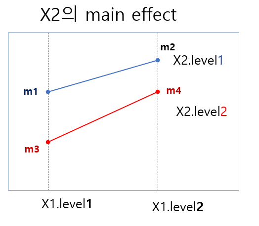

그림4.3-1

그림을 보면 X2의 레벨과 상관없이 X1의 차이는 m1에서 m2로 증가하고, m3는 m4로 변한다. 이런 경우는 상호작용효과가 발견되지 않고 주효과만 나타나게 된다. 상호작용 효과가 나타나지 않는 것을 이론적으로 설명하면 상호작용효과는 ’차이의 차이’라고 할 수 있다.

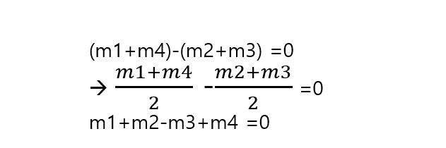

그림4.3-2

이를 다시한번 시각화하면 다음과 같이 나타난다. X1의 레벨이 변함에 따라 x2의 레벨이 거의 동일하게 변화하기 때문이다. **차이에 대한 차이**가 너무 적어지기 때문이다. 물론 통계적 검증을 거쳐야 정확하다.

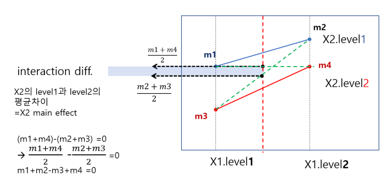

그림4.3-3

상호작용효과가 있는 경우는 다음과 같다. X1의 요인의 효과는 X2의 수준에 따라 다른 차이를 나타내고 있다. 이러한 경우가 상호작용효과가 나타나는 경우로 볼 수 있다. interaction의 차이가 매우 좋아서 통계적으로 유의한지 아닌지는 통계적 검증을 거치는 것이 필요하다.

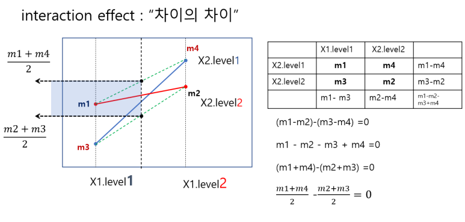

그림에서 보는 바와 같이 이러한 경우는 어느 정도 확실하게 통계적으로 유의하다.

**상호작용효과의 이해와 구체적인 예** 상호작용(interaction)이 발생할 수 있는 간단한 설정은 분산 분석(ANOVA)을 사용하여 분석된 2x2-요인 실험이다.  
우리가 두 개의 이항 인자 A와 B를 가지고 있다고 가정해보자. 예를 들어, 이러한 요인은 두 가지 치료 중 하나를 환자에게 투여했는지 여부를 나타낼 수 있다. 그런 다음 투여된 치료 조합의 함수로 각 환자에 대한 평균 치료 반응(예: 치료 후 증상 수준)을 고려할 수 있다.

*치료 A,B의 효과 model-1* 다음 표에는 가능한 한 가지 상황이 나와 있다.

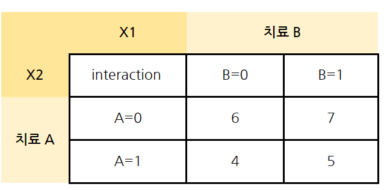

그림4.3.1. 모델1 - 치료A,B의 효과

jjstat패키지에서 interplot_data와 interplot함수를 이용하여 상호작용효과를 구성하고 시각화하여 이해해보자.

```r
interplot_data(6,7,4,5, type="mat")
```

먼저 이 두가지 치료법에는 상호작용효과는 없다.

```r
interplot_data(6,7,4,5, type="plot")
```

치료A의 주효과를 알아보자.

치료 B의 투여 여부에 관계없이 치료 A를 받지 않는 대상자평균(M = 6.5)과 치료 A를 받는 대상자의 평균(M = 4.5) 반응 차이는 2이기 때문이다.즉, A의 main effect는 2인 것이다.

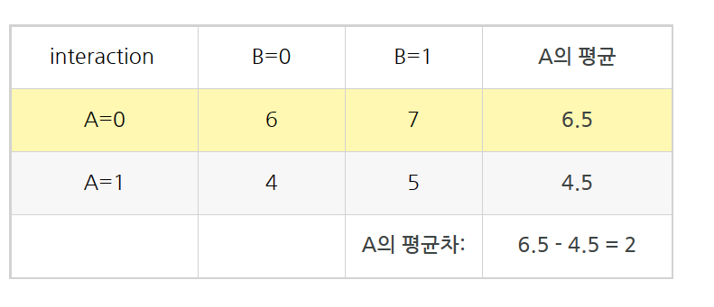

그림 4.3.2. 치료A의 주효과

치료B의 주효과를 알아보자.  
치료 B를 받지 않는 대상자 평균(M = 5)와 치료 B를 받는 대상자의 평균(M =6) 반응 차이는 치료 A의 투여 여부에 관계없이(|7 - 6| = |5 - 4|) 동일하다. 즉, 치료B의 주효과는 -1이다.

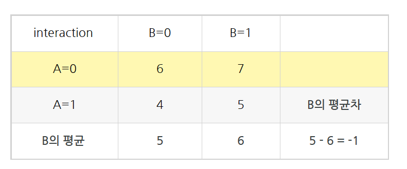

그림4.3.3. 치료B의 주효과

이번에는 다른 모델을 보자.  
아래와 같은 평균반응이 있었다고 하자.

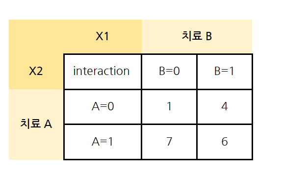

그림4.3.4. 모델2

이것을 행렬로 만들어보자.

```r
interplot_data(1,4,7,6, type="mat")
```

```r
interplot_data(1,4,7,6, type="plot")
```

각각의 주효과에 대해서 알아보자. 치료A의 주효과는 평균차가 2.5 - 6.5 =-4이다.  
치료B의 주효과는 4-5=-1이다.  
더 큰 숫자가 더 나은 반응에 해당한다고 가정할 때, 이 상황에서 치료 B는 대상자가 치료 A도 받지 않을 경우(A=0) 평균적으로 도움이 되지만 치료 A(A=1)와 함께 주어질 경우 평균적으로 해롭다( 7 -> 6 으로 감소 ). 치료 A는 치료 B도 투여하는지 여부와 상관없이 평균적으로 도움이 되지만 치료 B와 결합하기보다는 단독으로 투여하면 절대적, 상대적 측면에서 모두 도움이 된다고 해석한다.

**질적 및 양적 상호작용**

많은 애플리케이션에서 질적 상호작용과 양적 상호작용을 구별하는 것이 유용하다(Peto.D.P, 1982). A와 B의 양적 상호작용은 B의 효과의 크기가 A의 값에 따라 달라지는 상황이지만 B의 효과의 방향은 A의 모든 값에 대해 일정하다. A와 B의 질적 상호작용은 각 변수의 효과의 크기와 방향이 다른 변수의 값에 따라 좌우될 수 있는 상황을 가리킨다.

**(1) 양적 상호 작용** 평균 표는 양적 상호작용을 나타낸다. 치료 A는 B가 주어졌을 때와 주어지지 않았을 때 모두 유익하지만, B가 주어지지 않았을 때(즉, A만 주어졌을 때) 그 이득은 더 크다.

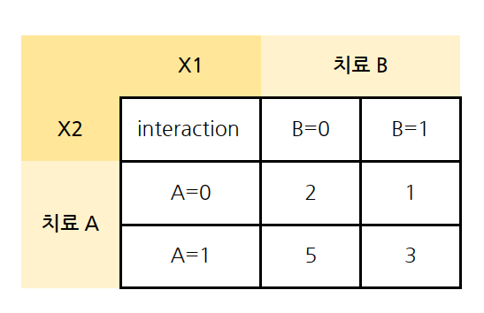

```r
interplot_data(2,1,5,3, type="mat")
```

```r
interplot_data(2,1,5,3, type="plot")
```

**(2) 질적 상호 작용**

평균 표는 질적 상호작용을 보여준다. A는 B를 주면 해롭지만, B를 주지 않으면 유익하다. A가 주어졌는지 여부에 기초하여 B의 이익을 고려한다면 동일한 해석이 유지될 것이라는 점에 유의한다.

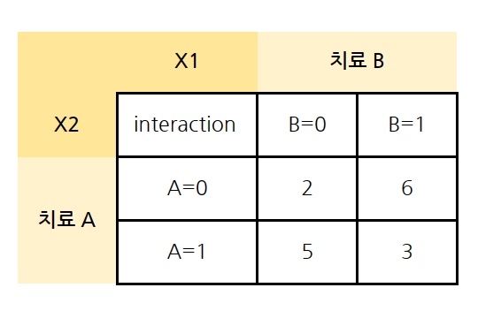

그림4.3.6. 질적 상호작용

```r
interplot_data(2,6,5,3, type="mat")
```

```r
interplot_data(2,6,5,3, type="plot")
```

치료B와 치료A의 주효과를 보자.

위 상호작용 효과는 치료B에 의해서 나타난 것이다. 치료A의 주효과는 없는 상태이다.  
질적 상호작용과 양적 상호작용의 구별은 변수를 고려하는 순서에 따라 달라진다(대조(in contrast), 부가성의 성질은 변수의 순서에 불변함).

**질적 상호작용의 다른 예**

다음 표에서 치료 A의 효과에 초점을 맞추면 양적 상호작용이 있다. 즉, 치료 A는 치료 B가 이미 주어졌거나 그렇지 않은지에 관계없이 평균적으로 결과를 개선할 것이다(치료 A만 주어지면 이득이 더 크다). 그러나 치료 B의 효과에 초점을 맞추면 질적인 상호작용이 있다.

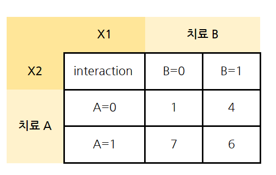

그림4.3.7. 질적 상호작용의 다른 예

즉, 이미 치료를 받고 있는 대상에게 치료 B를 주는 것은 (평균적으로) 상황을 악화시키는 반면, 치료 A를 받지 않는 대상에게 치료 B를 주는 것은 평균적으로 결과를 향상시킬 것이다.

```r
interplot_data(1, 4, 7, 6, type="mat")
```

```r
interplot_data(1, 4, 7, 6, type="plot")
```

생물종과 대기온도의 상호작용과 체온에 미치는 영향

다양한 공기 온도에서 다른 종의 체온에 대한 연구를 화씨 온도로 생각해 보라. 데이터는 아래 표에 나와 있다.

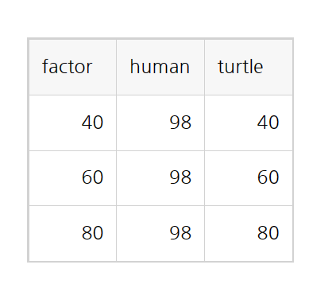

그림4.3.8. 질적 상호작용의 다른 예

```r
interplot_data(98,40,98,60, 98, 80, row = 3, col=2, type="mat" ) %>%
  `colnames<-`(c("air","body")) %>%
  `rownames<-`(c("40", "60", "80"))
```

```r
interplot_data(98,40,98,60, 98, 80, row = 3, col=2, type="plot" , xy=TRUE,
               yadd = 5)
```

```r
interplot_data(98,40,98,60, 98, 80, row = 3, col=2, type="plot" , xy = FALSE,
               yadd = 10)
```

**뇌졸중 심각도 및 치료가 회복에 미치는 영향**

두 번째 예로는 뇌졸중의 심각성과 환자의 생존에 대한 약물의 효능 사이의 상호작용에 대한 임상실험을 고려해 보십시오. 데이터는 아래 표에 나와 있다.

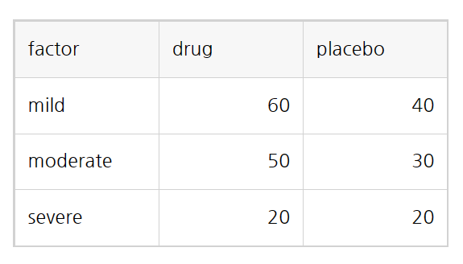

그림4.3.8. 질적 상호작용의 다른 예

```r
interplot_data( 60, 40, 50, 30, 20,20, row = 3, col=2, type="mat")
```

상호작용 그래프

```r
interplot_data( 60, 40, 50, 30, 20,20, row = 3, col=2, type="plot" ,
                xy = TRUE,
                yadd=5)
```

그래프 전환

```r
interplot_data( 60, 40, 50, 30, 20,20, row = 3, col=2, type="plot" ,
                xy = FALSE, yadd=5)
```

상호작용(interaction)도에서는 경미한 뇌졸중 그룹과 중간 뇌졸중 그룹에 대한 선이 평행하므로 약물이 두 그룹에서 동일한 효과를 가지므로 상호작용(interaction)이 없음을 나타낸다.

중증 뇌졸중 그룹의 라인은 다른 라인과 평행하지 않아 뇌졸중 중증도와 생존에 대한 약물 효과 사이에 상호작용이 있음을 나타낸다. 중증 뇌졸중 집단의 선이 평평해 이들 환자 중 약물치료와 위약치료 사이에 생존에 차이가 없음을 알 수 있다. 이와는 대조적으로 경미한 뇌졸중 그룹과 중간 뇌졸중 그룹의 선은 오른쪽으로 기울어져 있어 이들 환자 중 위약 그룹이 약물 치료 그룹보다 생존율이 낮다는 것을 알 수 있다.

### 4.3.2. Two way ANOVA 분석절차

일반적으로 다음이 절차를 따르면 분석하는데 무리가 없다. 이 분석에는 R에 내장된 lm(), anova()와 library(emmeans)를 이용하여 해결을 한다. 어떤 통계패키지를 사용한다 하더라도 크게 2단계의 절차를 따르게 된다. 첫번째는 2원분산분석을 통하여 상호작용효과가 있는지 확인하고 두번째에는 사후분석이 아닌 계획비교, 즉 대비검정(contrast)를 하게 되는데 이는 일원분산분석을 통해서 하게 된다. SPSS에서는 oneway ANOVA에 contrast 명령을 넣어서 할 수있다.

1. 2x2 anova 를 통한 상호작용 효과 검증
1. lm(DV ~ IV1*IV2) %>% anova 를 저장한다.
- SPSS처럼 type3의 방법으로 출력하려면 car패키지를 이용하면 된다.
2. 상호작용효과 유무를 확인한다. 상호작용이 존재한다면 이제는 대비검정을 수행한다.
2. 그룹별 기술통계 데이터를 추출  
   기술통계 데이터를 보고 group를 설정하여 상호작용효과에 대한 분해(decompose)를 해나갈 수 있다. 기술통계 자료는 dplyr의 group_by와 summrasie()를 이용하여 정리한다. 이결과는 다음의 2가지에 대하여 사용한다.

(1)상호작용 효과 그래프에 사용 (2) emmeans의 emmip()를 이용하여 plot그림

3. oneway ANOVA 와 contrast
1. group 설정작업 –> one way ANOVA를 위한 데이터

데이터가 많은 경우에는 반드시 filter()함수를 사용하여 새롭게 subset를 만들어서 한번에 합쳐야 분석하기 쉽다.

- 데이터가 적은 경우에는 edit()를 사용하여 그냥 추가하여 사용한다.
  2. emmeans() –> marginal means를 구한다.

  emmeans(회귀분석결과, 구분하는그룹)으로 값을 구한다. 그리고 이 값을하나의 변수로 저장한다.
  3. contrast 설정
  - 연구자의 분석에 맞게 효과를 분해한다.
  - 2*2에서 상호작용 효과는 m1-m2-m3+m4=0을 검정한다. 이것은 이미 다른 포스팅에서 자주 이야기를 하였다.
  4. contrast(marginal means, contr, adjust=“none” )

adjust=“bonfferoni”, or “bon”등을 설정하면 조절된 p값이 산출된다.

conflint() 신뢰구간을 나타내준다.

plot()- tukey분석과 비슷하게 연구자의 가설이 유의한지 점검해준다.

### 4.3.3. Two way ANOVA 분석

```r
Erotic_picture_love <- jjstat::Erotic_picture_love
Erotic_picture_love  %>%  str()
```

자료에 대하여 간단히 이해하자.

Balzarini, R. N., Bobson, K., Chin, K., and Campbell, L. (2017). Does exposure to erotica reduce attraction and love for romantic partners in men? Independent replications of Kenrick, Gutierres, and Goldberg (1989), Journal of Experimental Social Psychology, 70: 191-197. 여기에서 사용한 데이터는 Kenrick et al.(1989)의 study2데이터이다. 이 데이터를 이용하여 우리가 알아보고자 하는 2원분산 분석과 상호작용에 대하여 알아보려고 한다.

모델  
Erotic Pictures and Love: Factorial 2x2 Between Subjects ANOVA

```
- Gender - Participant's gender.
- Age - Participant's age.
- RelLen - Number of years in a current relationship.
- Condition - Experimental condition (Nudes = nude pictures, Abstract Art = abstract art pictures)
- PartnerAttractiveness - A sum of 6 Likert scales about the partner's attractiveness
              (1 = not at all, 9 = very much).
- LoveForPartner - A sum of 13 Likert scales from a Love Scale.
- AveragePleasantness - A mean of 3 items about pleasantness of the pictures.
```

정리하면 종속변수는 AveragePleasantness이고, 독립변수는 Gender와 Condition이다.

Two way ANOVA 및 상호작용효과 분석

```r
#A 2 (Gender: Male, Female) x 2 (Condition: Art, Nudes) ANOVA on pleasantness of the stimuli shows an interaction between Gender and Condition.
aov(AveragePleasantness ~ Gender*Condition, data =  Erotic_picture_love,
   contrasts = list(Gender = contr.sum, Condition = contr.sum)) %>%
  rstatix::Anova(type =3) %>%  round(3)
```

Two way anova, 상호작용효과에 대한 유의성 검정을 해보자.

```r
aov(AveragePleasantness ~ Gender*Condition, data =  Erotic_picture_love) %>%
  report_aov()
```

기술통계와 상호작용 효과 그래프  
tidyverse를 이용하여 기술통계를 나타내는 방법은 다음과 같다.

```r
Erotic_picture_love %>%
  group_by(Gender,Condition) %>%
  summarise(AP.Mean=mean(AveragePleasantness),
            SD=sd(AveragePleasantness), N=n())
```

다음은 jjstat에서 mysummaryBy()함수를 이용하여 기숥오계를 나타내는 방법이다.

```r
mysummaryBy(AveragePleasantness ~ Gender + Condition, data = Erotic_picture_love)
# DescribeBy(AveragePleasantness ~ Gender + Condition, data = Erotic_picture_love)
```

이제 상호작용 효과를 그려보자. 이를 위하여 플롯데이터를 만들어본 후에 그려보려고 한다. 물론 아래처럼 데이터를 생성하는 것이 아닌 jjstat::mysummaryBy을 이용하여 생성된 데이터를 활용하는 것이 더 편리할 수 있다. 다만 아래의 방법은 tidyverse를 이용하여 데이터를 생성하는 일반적인 방법이므로 이를 이용하여 데이터를 생성하여 상호작용효과를 그려볼 수 있다.

```r
epal.plot <-  Erotic_picture_love %>%
              group_by(Gender, Condition) %>%
               summarise(AP.Mean = mean(AveragePleasantness),
                       SD = sd(AveragePleasantness),
                       N=n())
epal.plot <- epal.plot %>%
                mutate_if(is.numeric, round, 2)  # 변수가 numeric인 경우만 round처리
epal.plot %>% head()
```

1. 상호작용 효과 그래프 그리는 방법 1: ggplot

기술통계 데이터를 이용하여 그리는 방법이다.

```r
#interaction plot####method 1

epal.plot   %>% ggplot(aes(x = Gender,y = AP.Mean))+
    geom_point(aes(col = Condition, shape = Condition),
               size = 4)+
    geom_line(aes(group = Condition, col = Condition, lty = Condition),
              lwd = 1.2)+
  geom_text(aes(y = AP.Mean+0.1,
                label= round(AP.Mean,2)))
```

데이터를 이용하여 상호작용 효과를 그리는 다른 방법으로는 jjstat패키지의 interplot을 이용하는 방법이 있다. 데이터에 대한 상호작용효과 그래프를 xy옵션을 이용하여 전환시킬 수 있으므로 상호작용효과를 표현하는데 편리하다. 먼저 musummaryBy를 이용하여 데이터를 축약한 후에 interplot을 이용하는 방법이다.

```r
 mysummaryBy(AveragePleasantness ~ Gender + Condition, data = Erotic_picture_love) %>%
  # mutate_if(is.numeric, round, 2) %>%
   interplot(hjust = 0,
            xy= T, vjust=-1, yadd=0.1,
            xlab = "Gender",
            ylab = "AveragePleasantness",
            legend_title = "Condition")
```

2. 상호작용 효과 그래프 그리는 방법 2: emmip()이용

이는 emmeans에서 ggplot를 상호작용 그래프를 쉽게 그리도록 만들어 둔 것이다.

```r
#emmip_interaction plot method 2
epal.aov <- aov(AveragePleasantness ~ Gender*Condition, Erotic_picture_love)
# epal.aov %>% anova()
epal.aov %>% summary()
```

```r
 ##plot
emmip.data <- emmeans::emmip(epal.aov, Condition ~ Gender )
#CIs
emmeans::emmip(epal.aov,
               Condition ~ Gender,
               CIs=TRUE )+
  geom_text(aes(y = yvar + 0.1, label = round(yvar , 2)), hjust = -.5)
```

데이터 정리 : 그룹 구분을 위한 그룹 변수 생성

일단은 데이터를 구분하기 위해서는 arrange를 통하여 확인하면 된다. 이렇게 정리하는 것은 일단은 데이터내에서도 구분을 쉽게 하기 위함이다. 물론 데이터를 코딩할 때 처음부터 구분되게 했으면 괜찮다. 실험연구에서 피험자가 적으면 그냥 입력해서 해도 되지만 데이터가 많을 때에는 구분해낼 수 밖에 없다. 2*2 상호작용을 보게 되므로 그룹을 4개로 나누어야 한다. 그룹을 나누어서 정리하는 방법은 사용자에 따라 고급기술이 많다. 아직 필자의 수준에서는 아래와 같은 방법이 가장 쉽고 편하기 때문에 필자의 방법을 소개한다.

```r
#oneway anova를 위한 데이터 그룹생성
epal_o <- Erotic_picture_love %>% arrange(Gender, Condition) %>%
  mutate(grp = case_when(
   Gender=="Female"& Condition=="Abstract Art" ~ "g1_FA",
   Gender=="Female"& Condition=="Nudes"       ~ "g2_FN",
   Gender=="Male"& Condition =="Abstract Art" ~ "g3_MA",
   Gender=="Male"& Condition =="Nudes"        ~ "g4_MN"  )
   )

#생성한 데이터의 그룹별 빈도수
epal_o$grp %>% table()
```

각 그룹은 g1_FA(58), g2_FN(41), g3_MA(64), g4_MN(60)로 생성했다. 그룹을 생성하는 이유는 사후분석, 즉 이중에 계획비교에서 대비검정(contraast test)를 할 때 one way anova를 이용하여 분석하기 편리하기 때문이다. 교육과 심리분야는 one way anova에서도 사후분석으로 일괄적으로 분석패키지를 돌리는 것다는 선행연구를 통한 가설을 세우고, 이를 통해 실험을 하는 것이 중요하다는 점을 강조했다. 따라서, 이러한 코딩에는 dplyr::case_when()를 이용하여 코딩하는 것이 편리하다고 할 수 있다.

##### 사전 계획 대비검정(planned contrast analysis)시행

먼저 그룹별로 기술통계치를 비교하여 사전에 분석할 데이터의 특징을 살펴보는 것이 필요하다.

```r
 mysummaryBy(epal_o, AveragePleasantness ~ grp)
```

그룹별 평균비교에 관하여 시각화를 통해서 좀 더 직관적으로 확인하여 데이터에 대한 이해를 높여보는 것이 필요하다. 가장 많이 활요하는 방법이 boxplot이다.

```r
#boxplot
ggplot(epal_o,
       aes(x = grp,y = AveragePleasantness))+
  geom_boxplot()+
  labs(title ="Comparison Boxplot by group")
```

library(emmeans)를 로디앟여 일원분산분석한 자료를 emmeans()에 넣고 구분자를 그룹변수를 설정해준다. R에서 일원분산분석 방법은 aov를 이용하거나 혹은 lm-anova 조합으로 둘 다 가능하다.

```r
#marginal means #####
library(emmeans)
epal.aov <- aov(AveragePleasantness ~ grp, epal_o)
epal.aov %>% anova()
```

**marginal means**

emmeans(일원분산분석결과, “그룹변수”)로 하는 방법과 emmeans(일원분산분석결과, ~ 그룹변수)를 넣는 2가지의 방법이 있다. 편한 방법을 사용하면 된다.

```r
epal.em <- emmeans(epal.aov, "grp")
epal.em

#이방법도 가능
 # emmeans(epal.aov, ~grp)
```

**대비 계수 설정**

대비계수는 list방식으로 설정해야 한다. 일반적으로 유명한 브랜드 대비가 존재하지만 실제로 연구자가 원하는 가설이 아닌 경우도 많고, 각 브랜드 대비의 방법을 외우기도 힘드니 가능한 연구자의 가설을 가지고 대비계수를 설정하면 된다.  
예를 들어 m1, m2, m3, m4를 가지고 상호작용 검증을 한다면 **차이의 대한 차이**가 바로 상호작용이다.

즉, 수식은 다음과 같이 이해할 수 있다.

[output not shown]

으로 검정하게 된다. 상호작용 효과에 대한 검정은 어느 방향으로 해도 마찬가지이다. 그러나, 단순주효과( simple main effect)는 내용을 보고 잘 평가하고 정리해야 한다. 그룹변수를 만들 때 그룹 변수명을 무작정 g1~g4보다는 이름을 알기 쉽게 적는 것도 방법이다. 대비계수의 합은 0이되어야 하며, 직교(벡터의 내적의 값이 0)이 되도록 설정한다.

대비검정 이제 contrast()를 사용하여 대비검정을 수행한다.

대비계수 설정

```r
#contrast coeff
contr = list(
          "interation: m1-m2-m3+m4=0"   = c(1, -1, -1, 1),
           "Con of Female: m1-m2=0"     = c(1, -1, 0, 0),
           "con of Male: m3-m4-0"       = c(0, 0, 1, -1),
           "Gender of Abstract: m1-m3=0"= c(1, 0, -1, 0),
           "Gender of Nudes: m2-m4=0"   = c(0, 1, 0, -1))
contr
```

대비검정 결과

```r
#result
contrast(epal.em,contr,adjust = "none")
```

p값을 잉용한 유의성 표시

```r
contrast(epal.em,contr,adjust = "none") %>%
  p_mark_sig()
```

p_mark_sig는 unite = TRUE로 하여 데이터속에서 유의성을 표시할 수 있다.

```r
contrast(epal.em,contr, adjust = "none") %>%
  p_mark_sig(unite = TRUE)
```

신뢰구간의 유의성을 확인해보도록 하자. confint함수를 이용하여 신뢰구간을 나타낼 수 있다.

```r
contrast(epal.em,contr,adjust = "none") %>%
                confint()%>%
                 confint_mark_sig(unite = TRUE)
```

신뢰구간에 plot함수를 이용하여 신뢰구간의 유의성을 시각화할 수 있다.

```r
contrast(epal.em,contr,adjust = "none") %>%
  plot()+
  geom_vline(xintercept = 0, linetype = 2)
```

**simple contrast**

보통 단순대비검정으로 하는 방법은 pairs를 이용한다. 이것은 쌍으로 모든 경우를 비교한다. 일단적으로 TukeyHSD와 비슷하다고 생각하면 된다.

```r
#simple contrast
pairs(epal.em, simple = "grp") %>%
  p_mark_sig(unite=TRUE)
```

pairs는 2개의 변수를 쌍으로 비교해주는 함수이다. pairwise하게 비교하여 유의성을 검정한다.

```r
#simple contrast
pairs(epal.em, simple = "grp")  %>%
  confint() %>%
  confint_mark_sig(unite=TRUE)
```

이를 시각화하면 다음과 같이 할 수 있다.

```r
#simple contrast
pairs(epal.em, simple = "grp")  %>%
  plot()+
   geom_vline(xintercept = 0, linetype = 2)
```

## 4.4. 반복측정 분산 분석

```r
# https://blog.naver.com/shoutjoy/223335403422
```

반복측정 ANOVA는 일원분산분석과 동일하지만 독립그룹이 아닌 곤련 그룹에 대한 것으로 paired t test의 확장이라고 할 수 있다. 그리고, 반복측정 ANOVA는 within-subjects ANOVA 라고도 한다. 종속변수는 연속형 변수(Continuous, interval or ratio)이며, 독립변수는 범주형 변수(categorical either nomial or ordinal)이다[1]. 반복측정 자료를 분석하는 대중적인 방법은 ANCOVA와 rANOVA(mixed-ANOVA)이다[2].

“반복측정 자료 분석 시 HLM(Hierarchical Linear Model)과 같은 다층모형(multilevel model)을 이용할 수 있다. 다층모형은 ANCOVA 또는 rANOVA와 비교 시 여러 가지 방법 론적 이점이 있다. 특히 결측자료를 분석하는 경우 그러하여, ANCOVA 또는 rANOVA가 완전자료(complete-case)만 분석할 수 있는 반면, 다층모형은 결측자료(missing data)를 무리 없이 분석할 수 있다. 따라서 결측이 있는 경우 다층모형의 검정력이 더 높고, 추정값의 편향(bias) 또한 상대적으로 적은 편이다. 또한 다층모형에서는 rANOVA에서의 구형성 가정 과 같은 가정 대신, 반복측정 자료에 대하여 다양한 상관계수 패턴을 다룰 수 있다는 장점 도 있다(Singer & Willet, 2003).”

### 4.4.1. Repeated ANOVA를 사용하는 경우

1. 3가지 이상의 시점에 걸치 평균점수의 변화, (2) 3개이상의 서로 다른 조건에서 평균점수 차이를 조사하는 경우에 사용한다. 학생이 공부한다면 공부전, 공부중, 공부후로 측정할 수 있고, 운동전, 운동중, 운동후로 측정할 수 있다. 혹은 동일한 사람에게 다른 종류의 케이크(A,B,C)를 맛보게 하는 맛을 평가하는 것들이 해당한다.

반복측정 ANOVA에서는 수준 혹은 관련 그룹이라는 범주가 존재한다. 즉, (1)의 사례에서 중요한 것은 시간이며, 이 시간이 독립변수가 된다. (2)의 사례에서 독립변수가 되는 것은 수준이나 관련 그룹이 되는 것이다. 보통 개체 내 요인(within-subjects factor) 이라고 부른다.

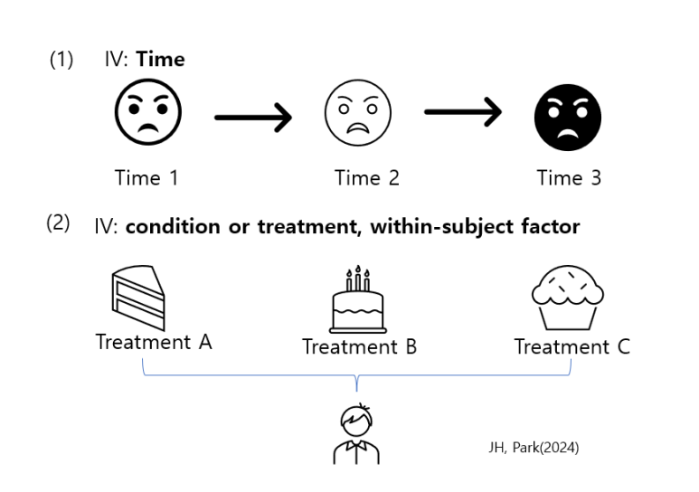

이러한 도식을 보면서 데이터의 구조를 어떻게 만들어가야할 지 이해가 되기도 한다. Time이나 condition. or treatment 등이 중요한 독립변수가 되고 있음을 알 수 있다. [Figure 2]에는 6명의 피험자가 참가하고 있다는 것을 알 수 있다.

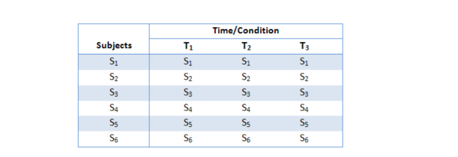

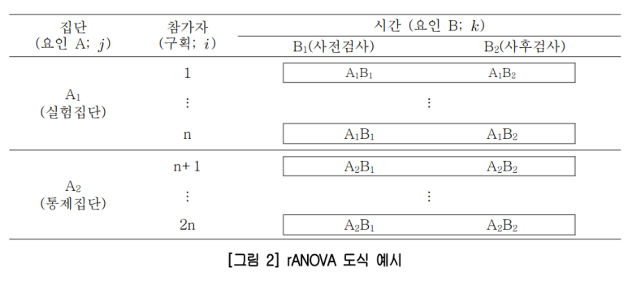

```
 H0(연구가설): 평균이 동일하다.
 H0 : µ 1 = µ 2 = µ 3 = … = µ k

 µ = 모집단 평균, k = 관련 그룹의 수를 나타낸다.

 H1(대립가설): 적어도 두개의 평균이 다르다.
```

반복측정 ANOVA는 다수를 포함하는 전체적인 통계(omnibus statistical test)이다. 따라서 대립가설이 채택된다면 사후분석(POST HOC)을 통하여 어느 시점이나 컨디션, 조치에서 차이가 발생했는지 알아보아야 한다.

### 4.4.2. 반복측정 ANOVA의 구조와 논리

#### 4.4.2.1. Repeated ANOVA 원리

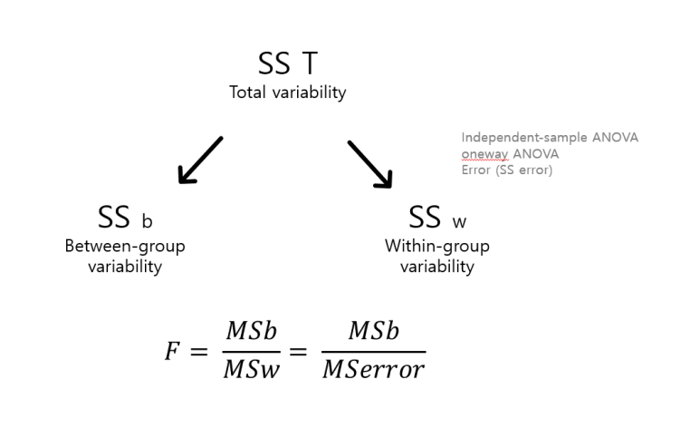

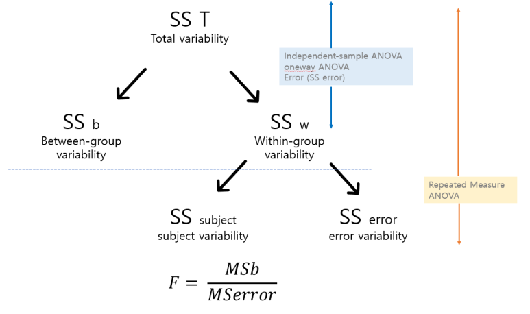

**기본가정: 구형성가정(sphericity assumption)**

첫째, 정규성 가정으로 개체수가 크다면 무리없다는 입장을 말한다.  
두번째는 구형성(Sphericity assumption)으로 두 개의 시점 사이의 측정치의 차이의 분산이 일정하고 각 군의 분산구조가 같다는 가정이다. 이러한 가정은 통상 Maucly’s test로 구형성 가정(H0: 자료가 구형성 가정을 만족)하고 Box의 동일성 가정(H0: 각 그룹간 분산구조가 같다)을 실시한다.

구형성 조건을 만족한다는 것은 각 반복측정치의 상관관계가 모두 동일하다는 의미이다. 일변량 분석하는 것이 더 정확하다. 즉 Tests of Within-subject Effects를 확인한다. 구형성이 만족되지 못하면 자유도 수정하는 그린하우스-가이서 혹은 훈펠트 수정계수를 사용한다.

즉, 구형성 가정은 반복측정 디자인(피실험자 내 디자인)의 경우 요구되는 가정으로 일원분산분석(피실험자간)의 경우 ’분산의 동일성 가정’에 해당한다고 볼 수 있다. 이는 연구 대상 집단들 중에서 어느 두 집단의 차이값들이 분산과 동일하다는 가정이다. 좀 더 구체적으로 이야기를 하면, 반복 처리간 상관이 동일함을 의미하는 복합 대칭성(compound symmetry)과 각 처리마다 처리 내 분산들이 동일함을 의미하는 등분산이 모두 만족되는지 보기 위함이다. 이를 수행하는 것이 바로 Mauchly의 구형성 검정이다. Mauchly의 구형성 검정에서 W가 1이면 완벽한 구형성(단위행렬)이 되며, 1에 가까울 수록 구형성이 강해진다는 것인데, 구형성 검정에서 귀무가설은 앞에서 말한바와 같이 “데이터가 구형성을 갖는다”라는 것이다. 즉 p > .05이면 구형성 가정을 충족시킨다는 의미이다.  
구형성 가정을 만족하는 경우 일변량 분석을 실시하게 되고, 구형성 가정을 만족하지 않는 경우에는 다변량 분석(Type III Repeated measures MANOVA tests)을 실시하거나 Greenhouse-Geisser방법으로 수정된 일변량 분석을 실시한다. 구형성 강정을 만족하는 데이터에 대하여 다변량 분석을 실시하면 검정력이 매우 떨어지게 되며, 다변량 분석도 공분산 행렬에 아무런 가정을 하지 않고 시행하지만 샘플수가 적으면 검정력이 떨어진다. 따라서 구형성 가정을 만족하지 못할 경우에 다변량 분석보다는 수정을 거친 일변량 분석을 시행하는데 그때 사용하는 것이 Greenhouse-Geisser, Huyng-Feldt방법 등이다.

#### 4.4.3. 반복측정 분산분석의 계산절차

먼저 데이터를 보자. 아래와 같은 데이터가 있다. 이 데이터는 6명의 참가자에 대하여 3번에 걸쳐 운동능력을 측정한 데이터이다. 첫음 측정후 3개월후, 6개월후의 운동능력의 변화를 기록한 데이터이다.

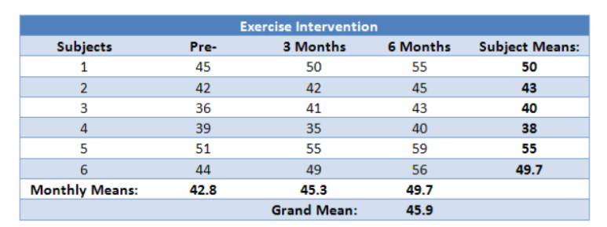

이 데이터를 R에 입력해보자. 입력은 data.frame으로 입력하였다.

```r
df_1 = data.frame(
        subject = c(1:6),
        mon1 = c(45, 42, 36, 39, 51, 44),
        mon3 = c(50, 42, 41, 35, 55, 49),
        mon6 = c(55, 45, 43, 40, 59, 56))
df_1
```

```r
jjstat::mysummary(df_1, "mon1","mon3","mon6")
```

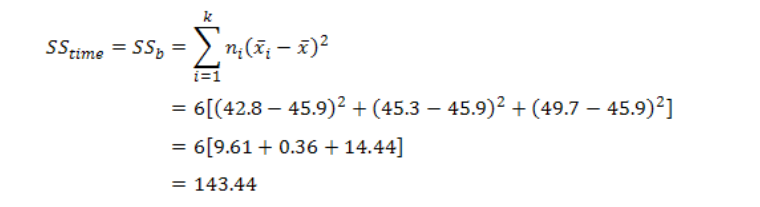

그림 수기계산

```r
SST <- df_1 %>% mutate(
  subject_mean = rowMeans(df_1[,-1]),
    m1.mean = mean(mon1),
    m3.mean = mean(mon3),
    m6.mean = mean(mon6),
    ground.mean = mean(subject_mean),
    N = length(mon1),
    m1.sq = (m1.mean- ground.mean )^2,
    m3.sq = (m3.mean- ground.mean )^2,
    m6.sq = (m6.mean- ground.mean )^2,
    SStime = sum( m1.sq + m3.sq + m6.sq)
    ) %>% jjstat::Round(2) #전체를 소숫점 2자리로 라운딩 처리
SST
```

```r
SST$SStime[1]
```

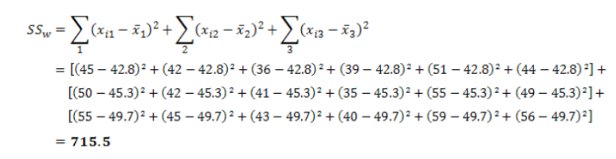

그림 수기계산

```r
# Within-groups variation (SSw) calculation

SSw <-df_1 %>% mutate(mon1_square = (mon1- mean(mon1))^2,
    mon3_square = (mon3 - mean(mon3))^2,
    mon6_square = (mon6 - mean(mon6))^2,
ssw = sum(df1$mon1_square) + sum(df1$mon3_square) +  sum(df1$mon6_square)

)
SSw$ssw[1]
```

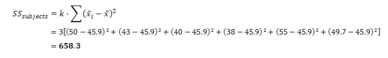

그림 Sum of square sunject

```r
SSsubject = SST%>% dplyr::select(2,3,4,5,9)%>%
mutate(SSsqu = (subject_mean - ground.mean)^2,
SSsub = sum(3* SSsqu)
 )
SSsubject
SSsubject$SSsub[1]
```

calculate SSerro

```r
## calculate SSerror

SSerror = SSw$ssw[1] - SSsubject$SSsub[1]
SSerror
```

```r
MStime = SST$SStime[1]/ 2
MStime    # 71.72222

MSerror = SSerror /((6-1)*(3-1))
MSerror   # 5.722222

F = MStime / MSerror
F
```

p값

```r
1- pf(F, df1 = 2, df2 = 10)
```

보고하는 방식은 다음과 같이 한다.

```
 F(dftime, dferror) = F-value, p = p-value
```

반복측정 ANOVA분석결과, 시간에 따른 차이는 통계적으로 유의미한 영향을 미치는 것으로 나타났다, F(2, 10) = 12.53, p = .002.

### 4.4.4. aov를 이용한 분석절차

이번에는 aov()함수를 사용하여 RM ANOVA를 시행해보자.

먼저 데이터는 long format으로 바꾸자.

- 데이터

```r
df_1 = data.frame(
        subject = c(1:6),
        mon1 = c(45, 42, 36, 39, 51, 44),
        mon3 = c(50, 42, 41, 35, 55, 49),
        mon6 = c(55, 45, 43, 40, 59, 56))
# df_1

df_long = df_1%>%
        tidyr::pivot_longer(names_to ="time",
                        cols = -subject)

df_long
```

반복측정 ANOVA를 분석하려면 aov()함수에서 Error()항목을 설정하면 된다. between에 해당하는 부분을 Error로 하여 분석에 넣으면 반복측정 분산분석이 가능하다.aov()함수의 설명에도 이와 같은 내용으로 설명이 되어있다.

```
 aov {stats}
 Fit an analysis of variance model by a call to lm (for each stratum if an Error(.) is used).
```

먼저 아노바분석을 해보자.

```r
aov(value ~ factor(time) + Error(factor(subject)), df_long)%>%
        summary()
```

broom::tidy()를 이용하여 정리하면 다음과 같다.

```r
aov(value ~ factor(time) + Error(factor(subject)),
    data = df_long)%>%
        broom::tidy()
```

time에 따른 기술통를 살펴보자. 측정월별로 기술통계값을 나타냈다.

```r
df_long_mean = df_long %>% mysummaryBy(value ~  time )
df_long_mean
```

좀 더 세밀한 정보는 rstatix패키지의 get_summary_stats를 이용하여 알아볼 수 있다. 이 함수를 이용하는 것은 어디까지나 데이터에 대한 상세한 정보를 알아보면서 데이터 탐색을 통한 데이터를 이해하는 것이 목표이므로 이러한 목적으로 사용하면 된다.

```r
df_long %>% group_by(time)%>%
rstatix::get_summary_stats(value)
```

월단위 평균을 시각화하여 비교해보자

```r
## graph
df_long %>%
  ggplot(aes(x = time, y = value))+
  geom_point(aes(color=subject), size=3, show.legend = FALSE)+
  geom_line(aes(group = subject, col=subject), show.legend = FALSE )
```

각각의 값들이 증가하는 방향으로 되어있다. 이에 대한 값들을 boxplot을 이용하여 알아보자.

```r
df_long %>%
  ggplot(aes(x = time, y = value))+
  geom_boxplot()
```

```r
# boxplot(value  ~ subject, data = df_long )
df_long %>%
  ggplot(aes(x = factor(subject), y = value))+
  geom_boxplot()
```

주효과와 상호작용 효과를 시각화해보자. HH퍀지를 통하여 미리 확인해 볼 수 있다.

```r
library(HH)
interaction2wt(value  ~ time*subject, data = df_long )
```

```r
df_long %>% ggplot(mapping = aes(x = value)) +
geom_histogram(bins = 4)+
facet_wrap(~ time)
```

Repeated measures ANOVA

df_long %>% rstatix::anova_test(value ~ factor(time) + **Error(subject/time)**)

bold처리한 부분을 맞게 집어 넣어야 한다.

rstatix패키지의 anova_test()를 이용하여 분석하면 RM ANOVA, 구형성검정, 동질성 검정을 함께 해준다.이를 통한 통계적 검증이 가능하다.  
첫번째 방법으로는 formula를 이용하여 사용하는 방식이 있다. **Error(subject/time)** 은 개체(subject)에 의해서 설명되는 분산으로 이에 대응하는 추가적인 오차항을 분리한다. `/time`인자의 표시는 개체가 적용되는 반복측정인자(repeated measure foctor)로 설정하는 것이다.

aov함수를 이용한 분석

```r
aov(value ~ factor(time)  + Error(subject/time) , data=df_long) %>%
  summary()
```

```r
# repeated measures ANOVA
df_long %>% rstatix::anova_test(value ~ factor(time)  + Error(subject/time) )
```

동일한 결과는 방식으로는 변수를 지정하는 방식으로도 가능하다.

```r
# or use character vector
df_long %>%
  rstatix::anova_test( dv = value, wid = subject, within= c(time))
```

```r
# Extract ANOVA table and apply correction
df_long %>% rstatix::anova_test(value ~ factor(time)  + Error(subject/time))%>%
rstatix::get_anova_table(., correction = "GG")
```

사후분석 다중분석

```r
df_long %>% rstatix::pairwise_t_test(value ~ time, paired =TRUE)
```

```r
df_long %>% rstatix::pairwise_t_test(value ~ time, paired =TRUE,
p.adj ="bonferroni")
```

## 4.5. MANOVA(다변량 분석)

다변량 분석(MANOVA)은 두 개 이상의 종속변수가 존재할 때, 각 종속변수 간의 상관관계를 고려하여 집단 간의 차이를 검정하는 통계 분석 방법이다. ANOVA(분산분석)의 다변량 확장 버전이라고 생각하면 된다. 즉, ANOVA는 단일 종속변수에 대한 집단 간 차이를 검정하는 반면, MANOVA는 여러 종속변수를 동시에 고려하여 집단 간 차이를 분석하는 기법이다.

MANOVA는 여러 종속변수를 동시에 분석하여 연구 효율성을 높일 수 있는 강점이 있다. 또한 종속변수 간의 상관관계를 고려하여 분석하기 때문에 통계적 검정력을 향상시킬 수 있으며 ANOVA보다 더 많은 정보를 제공하여 연구 결과를 더 풍부하게 해석할 수 있다.

**MANOVA의 주요 가정**

종속변수들은 다변량 정규분포를 따르며, 종속변수 간의 공분산 행렬은 모든 집단에서 동일하다. 또한 각 종속변수는 독립적이어야 한다.

### 4.5.1. MANOVA의 통계 검정

MANOVA에서는 다음과 같은 통계 검정을 수행한다.

```
- Wilks' Lambda: 종속변수 벡터의 평균 벡터가 집단 간에 동일한지 검정
- Pillai's Trace: 집단 간 차이의 크기를 나타내는 지표
- Hotelling-Lawley Trace: 집단 간 차이의 크기를 나타내는 또 다른 지표
 - Roy's Largest Root: 집단 간 차이를 설명하는 가장 큰 변수를 나타내는 지표
```

MANOVA는 다양한 분야에서 활용되고 있는데, 심리학에서는 성격, 지능, 태도 등 여러 심리적 변수를 동시에 분석하고, 교육분야에서는 학습 성취도, 학습 태도 등 여러 교육 변수들을 동시에 분석한다. 의학에서는 질병의 증상, 검사 결과 등 여러 의학적 변수를 분석하고, 마케팅분야에서는 소비자의 구매 행동, 인식, 태도 등 여러 변수를 동시에 분석하는데 활용된다.

분석에 활용할 데이터는 Skulls데이터(The structure of the data looks like this)이다.시대별 할당된 두개골 데이터로 c4000BC c3300BC, c1850BC, c200BC 및 cAD150 수준의 순서 요소이다. 여기서 연도는 대략적으로만 제공된 값이다. 각 변수명은mb(두개골의 최대 폭), bh(두개골의 기본 높이), bl(두개골의 기본 길이), nh(두개골의 비강 높이)로 구성이 되어있다. epoch는 이집트 역사의 다음 기간에 해당한다. 초기 왕조 시대 (BC 4000 년경); 후기 왕조 시대 (BC 3300 년경); 제 12 및 제 13 왕조 (BC 1850 년경); 프톨레마이오스 시대 (BC 200 년경); 로마 시대(서기 150년경).  
이 데이터의 주요 포인트는 측정치가 시간이 지남에 따라 변하는가 하는 것이다. 시간이 지남에 따라 두개골의 일정하지 않은 측정은 이민자 집단과의 교배를 나타내는 것으로 볼 수 있다.

```r
library(heplots)
str(Skulls)
```

epoch에 따른 각 변수별 평균값을 구해보자. dplyr패키지의 summarise_all()함수를 이용하면 한번에 여러가지 변수의 평균을 구할 수 있다. 이때 함수는 list()를 이용하여 감싸야 한다.

```r
# method 1
Skulls %>% group_by(epoch) %>%
  summarise_all(list(mean))
```

다른 방법으로는 summmarise_at()을 이용하여 필요한 변수만을 선택하는 방법이 있다.

```r
#method2
Skulls %>% group_by(epoch) %>%
  summarise_at(c("mb","bh","bl","nh"), mean)
```

R base에는 aggregate함수를 이용하여 이를 나타낼 수 있다. 종속변수들은 cbind()를 이용하여 묶어주어야 한다. jjstat패키지의 Round()함수는 변수중에서 numeric변수만을 판별하여 자리수를 조절해준다.

```r
# method 3

aggregate(cbind(mb,bh,bl,nh) ~ epoch , data = Skulls, mean) %>%
  Round()
```

**manova 분석**

사용방법은 다음과 같다.

```
usage.
manova( cbind(independent variable,...) ~ independent variable, data= data)
```

클래스 ’manova’는 클래스 ’aov’와 요약(summary) 방법을 선택할 때 차이가 있다. 함수 manova는 aov를 호출한 다음 각 계층의 결과 객체에 맞게 클래스 ’manova’를 추가하는 방식으로 분석하여 요약한 것을 제시한다.

```r
# pretest
manova(cbind(mb,bh,bl,nh)~ epoch, data=Skulls)
```

[output not shown]

manvoa를 이용하여 `Skulls` 데이터셋의 `epoch` 변수에 따른 네 가지 종속 변수(`mb`, `bh`, `bl`, `nh`)의 변화를 분석한 결과는 다음과 같다.

1. **mb**: `epoch`의 변화에 따른 `mb`의 변동성은 502.827로, 잔차(residuals)는 3061.067이다. 이는 `epoch`의 변화가 `mb`의 변동성의 일부를 설명한다는 것을 의미한다.
2. **bh**: `epoch`의 변화에 따른 `bh`의 변동성은 229.907로, 잔차는 3405.267이다. 이는 `epoch`의 변화가 `bh`의 변동성의 일부를 설명한다는 것을 의미한다.
3. **bl**: `epoch`의 변화에 따른 `bl`의 변동성은 803.293으로, 잔차는 3505.967이다. 이는 `epoch`의 변화가 `bl`의 변동성의 상당 부분을 설명한다는 것을 의미한다.
4. **nh**: `epoch`의 변화에 따른 `nh`의 변동성은 61.200으로, 잔차는 1472.133이다. 이는 `epoch`의 변화가 `nh`의 변동성의 작은 부분만을 설명한다는 것을 의미한다.

이 결과는 각 종속 변수가 epoch에 따라 어떻게 변하는지를 보여준다. 잔차는 epoch에 의해 설명되지 않는 변동성을 나타낸다. 이는 모델이 데이터를 완벽하게 설명하지 못하고, 다른 요인들이 각 종속 변수의 변동성에 영향을 미칠 수 있음을 나타내는 것이다. 또한, 잔차의 표준 오차는 각 종속 변수에 대한 모델의 정확도를 나타내는 값이다. 이 값이 작을수록 모델의 예측이 더 정확하다는 것을 의미한다. 마지막으로, “Estimated effects are balanced”는 모델의 추정 효과가 균형을 이루고 있다는 것을 나타내는데, 이는 모델이 데이터를 잘 적합하고 있다는 것을 의미한다.

jjstat패키지에서 report_manova를 이용하여 type=II테스트에 의한 아노바(ANOVA)결과와 사후분석 결과 및 다변량 테스트 결과를 얻을 수 있다.

```r
skull_manova = manova(cbind(mb,bh,bl,nh) ~ epoch, data = Skulls) %>%
  report_manova("all")
skull_manova
```

이 결과를 살펴보자.

```r
skull_manova[[1]]
```

[output not shown]

두개골의 측정값의 평균이 시대별로 차이가 나는지 확인하기 위한 값이다. 종속변수(4가지 유형, 폭(mb), 높이(bh), 길이(bl), 높이(nh))에 따른 집단간(5개의 시대)에 대한 차이에 대하여 다변량 분석을 시해한 결과, 시대(epoch)에 따라 두개골의 측정값은 통계적으로 유의하게 다르다고 할 수 있다($F$(16, 580) = 3.512, $p$ < .001).

이를 위하여 일변량 분산분석을 시행한 결과는 다음과 같다.

```r
skull_manova[[3]]
```

다음은 “Pillai”, “Wilks”, “Hotelling-Lawley”, “Roy” 4가지 테스트 방법에 따라 값을 구한 것은 타낸 것이다.

```r
skull_manova[[4]]
```

heplot은 다음과 같은 시각화를 제공하는데, Scatterplot은 두 변수 간의 관계를 시각화하여 각 시대별로 어떻게 변화하는지 확인한다. heplot (Hypothesis Ellipses)은 다변량 분산 분석에서 사용된 선형 및 이차적인 효과를 시각화하는데 사용한다. 이를 통해 시대별로 변수들이 어떻게 변화하는지 확인할 수 있다.

```r
heplots::heplot(manova(cbind(mb,bh,bl,nh)~ epoch, data=Skulls))
```

```r
# HE plots
heplots::heplot(manova(cbind(mb, bh, bl, nh) ~ epoch, data=Skulls),
       hypotheses=list(Lin="epoch.L", Quad="epoch.Q"))
       # xlab=vlab[1], ylab=vlab[2])
```

이번에는 pair함수를 이용하여 다변량 데이터를 시각화해보자.

```r
vlab <- c("maxBreadth", "basibHeight", "basialLength", "nasalHeight")
pairs(manova(cbind(mb, bh, bl, nh) ~ epoch, data=Skulls),
      hypotheses=list(Lin="epoch.L", Quad="epoch.Q"),
      var.labels=vlab)
```

이번에는 scatterplot은 car::scatterplot을 이용해보자.

```r
vlab <- c("maxBreadth", "basibHeight", "basialLength", "nasalHeight")
car::scatterplot(mb ~ bh|epoch, data=Skulls,
            ellipse = list(levels=0.68),
            smooth=FALSE,
            legend = list(coords="topright"),
            xlab=vlab[2], ylab=vlab[1])
```

```r
car::scatterplot(mb ~ bl|epoch, data=Skulls,
            ellipse = list(levels=0.68),
            smooth=FALSE,
            legend = list(coords="topright"),
            xlab=vlab[3], ylab=vlab[1])
```

### 4.5.2. MANOVA 상호작용효과가 있는 경우

```r
## Example on producing plastic film from Krzanowski (1998, p. 381)
Y <- cbind.data.frame(
  tear=c(6.5, 6.2, 5.8, 6.5, 6.5, 6.9, 7.2, 6.9, 6.1, 6.3,
          6.7, 6.6, 7.2, 7.1, 6.8, 7.1, 7.0, 7.2, 7.5, 7.6),
   gloss=c(9.5, 9.9, 9.6, 9.6, 9.2, 9.1, 10.0, 9.9, 9.5, 9.4,
           9.1, 9.3, 8.3, 8.4, 8.5, 9.2, 8.8, 9.7, 10.1, 9.2),
    opacity=c(4.4, 6.4, 3.0, 4.1, 0.8, 5.7, 2.0, 3.9, 1.9, 5.7,
             2.8, 4.1, 3.8, 1.6, 3.4, 8.4, 5.2, 6.9, 2.7, 1.9),
   rate = gl(2,10, labels = c("Low", "High")),
   additive = gl(2, 5, length = 20, labels = c("Low", "High")) )

str(Y)
```

MANOVA결과는 다음과 같다. 상호작용 효과가 나타나 있기 때문에 더 많은 내용이 나타났다.

```r
manova(cbind(tear, gloss, opacity) ~ rate * additive, data=Y)
```

이제 이를 reprot_manova를 이용하여 내용을 확인해보자.

```r
manova(cbind(tear, gloss, opacity) ~ rate * additive, data=Y) %>%
  report_manova("all")
```

[output not shown]

단일 변수 ANOVA 테이블을 보면, RATE의 F-통계량은 유의하였다.$F$(3, 14) = 7.5543, $p$ = 0.003034. ADDITIVE의 F-통계량도 유의하였다. $F$(3, 14) = 4.2556, $p$ = 0.024745. 또한, RATE와 ADDITIVE의 상호작용도 유의하지 않았다. $F$(3, 14) = 3385, $p$ = 0.301782)

각 집단별로 일원분산분석을 진행한 결과, rate_tear, additive_tear, rate_gloss만 통계적으로 유의하였다. 샇호작용 효과는 각각의 테스트결과에서도 모두 유의한 것은 존재하지 않았다.

## 4.6. ANCOVA 공분산 분석

공분산 분석은 공변량을 추가로 모형에 투입하여 공변량이 결과변수에 미치는 효과를 통제하는 확장된 분산분석의 일종이다(김영석, 2017).

공변량은 결과변수와 상관관계를 맺고 있다고 가정되어야 하며, 공변량과 결과변수의 관계는 실험집단에 따라 다르지 않다고 가정이 되어야 한다. 그리고 공변량은 분산분석에 투입되는 독립변수들과 독립적 관계를 가진다고 가정이 되어야 한다. 즉, 예측변수들과는 상관관계가 맺지 않는다는 가정하에 분석이 된다.

이러한 가정하에는 공변량이 결과변수에 미치는 효과는 요인이 종속변수에 미치는 효과와 독립적이라고 할 수 있다. 공분산 분석은 분산분석에 연속형 변수를 추가한 것이다. 분산분석과 방법은 동일하지만 통제가 안되는 연속형변수(공변량)을 추가하여 오차를 줄이고 검정력을 높이는 방법이다.

공분산 분석을 하려면 몇가지 가정에 대하여 충족하는지 알아보는 것이 필요하다. 실험이 잘 통제된 공간에서는 분산분석을 이용하여 요인을 가지고 결과변수를 설명할 수 있을 것이다. 그러나 실제로는 사회과학에서 그러한 통제는 쉽지 않기 때문에 다른 변인을 통제하여 조사하고자 하는 변수만의 효과를 검정하게 된다.

공분산 분석은 분산분석에 연속형 변수를 추가하는 것이다. 궁극적인 목적은 각 그룹간 평균들의 차이가 있는지 검정하는 것이지만, 통제가 안되는 연속형 변수(covariate)를 추가하여 오차를 졸이고 검정력을 높이는 것이다(안재형, 2011).

### 4.6.1. 분석데이터의 시각화

사용할 자료는 moomBook 패키지의 acs데이터를 활용하고자 한다.

857명의 인구통계학적 데이터와 실험실 데이터가 포함된 데이터 세트. 급성 관상동맥 증후군(ACS) 환자의 인구통계학적 데이터가 포함된 데이터 세트이다.

주요 변수는 다음과 같다.  
BMI : body mass index in kg/m2  
smoking : history of smoking, One of the followings : “Never”,“Ex-smoker”,“Smoker”

```r
acs <- moonBook::acs
acs$smoking<-factor(acs$smoking, levels = c("Never","Ex-smoker","Smoker"))
acs %>% str()
```

그룹별 기술통계

```r
mysummaryBy(age ~ smoking, data = acs)[1:4] %>%
  Round(2)

#같은 결과에 대한 다른 방법
# # acs %>% group_by(smoking) %>%
#            summarise(M = mean(age),
#                      SD = sd(age),
#                      N = n())
```

평균비교 그래프

평균비교 그래프는 다음과 같다. smoking변수에서 Smoker가 심근경색에 걸리는 나이가 제일 어린 것으로 나타나고 있다. 이대로라면 담배를 끊는게 병에 안걸릴 확률이 높다고 말할 수 있을 듯 하다.

```r
#흡연에 따른 그래프 #####
library(ggplot2)
ggplot(acs, aes(x=smoking, y=age,fill=smoking))+geom_boxplot()
```

이를 막대그래프로 표준오차를 설정하여 표현한 것이다.

```r
ggplot(acs, aes(x=smoking, y=age,fill=smoking))+
  stat_summary(fun="mean", geom="bar",position="dodge")+
  stat_summary(fun.data = mean_se, geom = "errorbar", position="dodge",width=.8)
```

### 4.6.2. 공분산 분석을 위한 가정

산점도와 선형성 가정 linearity assumption

종속변수와 공변량은 서로 선형성이 존재해야 한다

먼저 산점도를 보자.

```r
#linearity assumption ####
# plot(age~BMI, data = acs,
#      pch=21,
#      bg=adjustcolor(c("red","green","blue")[acs$smoking],alpha=0.2))
ggplot(acs, aes(x=BMI, y=age, color=smoking))+
        geom_point()+
        # geom_smooth(method="lm", se= FALSE ,fill="gray80")+
  labs(title = "BMI별 급성곤동맥 증후군 발생 나이(age)")+
  theme_minimal()
```

고밀도로 퍼저있다는 것을 알 수 있다. 그냥 봐서는 선형성이 잘 보이지 않고 있다. ggplot을 이용하여 선형성을 표시할 수 있다. 종속변수와 공변량의 관계를 가지고 선형성을 표시하는게 필요하다. 이를 그리려면 많은 시간이 소요되는데, 일단은 ggplot로 원하는 그림을 좀 더 빠르게 그려진다.

```r
# ggplot
ggplot(acs, aes(x=BMI, y=age, color=smoking))+
        geom_point()+
        geom_smooth(method="lm", se= FALSE ,fill="gray80")+
  labs(title = "BMI별 급성곤동맥 증후군 발생 나이(age)")+
  theme_minimal()
```

회귀기울기의 동질성

요인과 공변량은 서로 상호작용이 없다는 것을 확인해주어야 한다.

```r
lm(age ~ smoking*BMI, acs) %>% rstatix::Anova(type=3)
```

잔차의 정규성

회귀분석

```r
#잔차의 정규성 ######
fit1 <- lm(age ~ BMI+ smoking, moonBook::acs)
fit1 %>% summary()
```

적합치와 잔차분석

```r
#적합치와 잔차를 분석 broom- augment
model.metrics <- broom::augment(fit1) %>%
  dplyr::select(-.hat, -.sigma) #remove detail
model.metrics
```

```r
library(rstatix)
acs<-moonBook::acs
#공분산 분석
res.aov <- acs%>% anova_test(age ~ BMI + smoking)
res.aov   # 아래의 결과와 동일
get_anova_table(res.aov) # 분석결과 table
```

결과보고

사후분석

```r
# Pairwise comparisons
pwc <- acs %>%
  emmeans_test(
    age ~ smoking, covariate = BMI,
    p.adjust.method = "bonferroni"
  )
pwc
```

결과보고

estimated marginal means

```r
get_emmeans(pwc)
```

ANCOVA 시각화

```r
library(ggpubr)
# Visualization: line plots with p-values
# Visualization: line plots with p-values

pwc <- pwc %>% add_xy_position(x = "smoking", fun = "mean_se")

ggline(get_emmeans(pwc), x = "smoking", y = "emmean") +
  geom_errorbar(aes(ymin = conf.low, ymax = conf.high), width = 0.2) +
  stat_pvalue_manual(pwc, hide.ns = TRUE, tip.length = FALSE) +
  labs(
    subtitle = get_test_label(res.aov, detailed = TRUE),
    caption = get_pwc_label(pwc)
  )
```

공분산 분석(ANCOVA)의 정규성 가정이 위반된 경우는 rank-ANOVA를 실행한다.

# 5. 연관성을 이용한 분석

상관분석

## 5.1. Correlation

상관분석은 두 연속변수가 서로 관련이 있는지 검정하는 통계분석이다. 상관분석을 통해서 두 변수가 어느정도의 관계가 있는지 파악할 수 있다. 상관계수의 값은 -1 ~ 1사이의 값을 가ㅣ져 1에 가까울 수록 관련성이 높은 것으로 본다. 값이 양수이면 정비례, 음수이면 반비례 관계를 나타낸다.

### 5.1.1. 상관계수

상관계수는 cor()을 이용하여 상관계수를 찾는다.  
두 개의 변수를 지정하면 두 변수 사이의 관계가 나타난다.

```r
cor(mtcars$mpg, mtcars$hp)
```

변수를 3개로 하면 3개의 변수가 나타난다. R의 베이스에서 변수 선택방벙을 이용하여 나타내었다.

```r
#R base를 이용한 상관계수
mtcars[, c("mpg","hp","wt")] %>%
  cor()
```

tidyverse이 방법을 사용하면 다음과 같다. 익숙해지면 이 방법이 더 편리한 것으로 생각 된다.

```r
#tidyverse를 이용
mtcars %>%
  dplyr::select(mpg, hp, wt) %>%
  cor()
```

더 많은 변수로 구성된 경우를 상관행렬을 얻어보자.

```r
#다변량으로 구성된 경우
mtcars[,1:7] %>%
  cor() %>%
  round(3)
```

많은 변수의 상관을 구할 수 있다. cor()함수는 상관계수만을 구해주는 것이며, 유의성 검정을 해주지는 않는다. 따라서, 유의성 검정은 별도로 해야 한다.

### 5.1.2. 상관계수의 유의성 검정

두 변수와의 상관관계는 통계적으로 유의한 것인지 알아보자.  
이때 사용하는 함수는 cor.test()함수이다.  
이 함수의 경우는 2개의 변수만을 입력해야 한다.

```
cor.test(변수1, 변수2)
```

이러한 형태로 입력하면 된다.

```r
cor.test(mtcars$mpg, mtcars$hp)
```

[output not shown]

mpg(연비)와 마력(hp)의 상관은 -0.78이고, 통게적으로 유의하다(p < .001).

The Pearson’s product-moment correlation between mtcars$mpg and mtcars$hp is negative, statistically significant, and very large (r = -0.78, 95% CI [-0.89, -0.59], t(30) = -6.74, p < .001).

이 결과는 report package를 이용하여 보고서를 작성한 것이다.

```r
#report
cor.test(mtcars$mpg, mtcars$hp) %>%
  report::report()
```

### 5.1.3. 상관계수의 시각화

보통 상관계수를 시각화하면 여러가지 면에서 빠른 파악이 된다. 간단하게 시각화하여 내용을 파악하는 방법과 응용하는 방법을 알아보자.

#### 5.1.3.1 히트맵을 그리는 corrplot

히트맵을 이욯하여 시각화하면 상관의 정도를 파악하는데 유리하다. corrplot패키지를 이용하여 시각화하면 화려한 모습을 나타나게 된다.

```r
#heatmap
library(corrplot)
cor(mtcars[,1:7]) %>%
  corrplot()
```

동그라미의 크기로 상관을 파악하고 색으로 판단이 된다. 그러나 정확한 수치(number)를 아는 것이 더 편리할 것이다.  
method = “number”로 하면 숫치로 나타나게 된다.

```r
cor(mtcars[,1:7]) %>%
  corrplot(method ="number")
```

이를 좀 더 다듬에서 행렬의 하위 부분에 나타내고, 대각선 부분의 1은 없앤 상태로 나타내 보자. 색은 음의 상관이면 “red”쪽으로 나타나고, 양의 상관은 “blue”쪽으로 나타나도록 설정하였다.

```r
cor(mtcars[,1:7]) %>%
  corrplot(method ="number",  #숫자로 표시
           type = "lower",   #아래 행렬만 표현
           tl.col = "gray10", #변수명 색 지정
           diag = FALSE,
           addCoef.col = "black",
           col=c("red","tomato","gold","skyblue","steelblue","blue")
  )
```

#### 5.1.3.2. rstatix패키지를 이용한 시각화(cor_plot)

rstatix를 이용하는 것도 실은 corrplot을 이용한 것이나 마찬가지이다. 이를 기반으로 만들어진 것이라서 그런 것인데, rstatix패키지는는 실제 논문에서 적용하기 좋은 형태로 분석의 결과를 제시해주기 때문에 매우 의미있는 패키지이다.

**cor_mat()**  
먼저 데이터에서 cor_mat()를 이용하여 상관행렬을 만들어내는 것이 중요하고 이를 이용하여 분석을 한다. 데이터를 저장하기 보다는 최대한 데이터에서 상관행렬을 만드는 것들을 보여주면서 설명하고 있다.

```r
library(rstatix)
mtcars %>%
  dplyr::select(mpg, disp, hp, drat, wt, qsec) %>%
  rstatix::cor_mat()
```

**(1)시각화**  
corrplot과의 차이점은 유의하지 않은 곳은 ’x’로 표시를 해주고 있다.  
사용은 cor_plot()만 입력하면 되는데, corrplot과도 옵션이 동일하다.

```r
#cor_plot
mtcars %>%
  dplyr::select(mpg, disp, hp, drat, wt, qsec) %>%
  rstatix::cor_mat() %>%
  cor_plot()
```

**(2)상관게수를 수치로 나타낸 것** 이번에는 상관계수를 수치로 나타낸 것이다. method = “number”를 설정하면된다. 또한 변수명등 심미적으로 더 보기좋게 나타나고 있다.

```r
mtcars %>%
  dplyr::select(mpg, disp, hp, drat, wt, qsec) %>%
  rstatix::cor_mat() %>%
  cor_plot(method = "number")
```

**(3)lower로 나타내기**  
rstatix::cor_plot() 먼저 행렬을 lower부분만을 나타내려면 type =“lower”로 표시하면 된다.

```r
mtcars %>%
  dplyr::select(mpg, disp, hp, drat, wt, qsec) %>%
  rstatix::cor_mat()%>%
  cor_plot(method = "number", type = "lower")
#diag =FALSE옵션은 수행되지 않음
```

다른 방법으로는 pull_lower_triangel()함수를 이용하여 실제로 행렬을 하위부분만 나타낸 후에 cor_plot()을 적용하는 방법도 있다.

먼저 pull_lower_triangel()을 적용하면 다음과 같다. 상관행렬을 보기 좋게 만들어준다.

```r
# pull lower triangle and visualize
mtcars %>%
  dplyr::select(mpg, disp, hp, drat, wt, qsec) %>%
  rstatix::cor_mat() %>%
  pull_lower_triangle()
```

cor+plot()에서 diag=FALSE 옵션은 수행되지 않는다. 따라서, 행렬을 수정하여 상관행렬 히트맵을 그리는 방법이 가능하다. diagonal = TRUE 옵션을 켜서 위에 보여준 히트맵과 동일하게 설정하였다.

```r
mtcars %>%
  dplyr::select(mpg, disp, hp, drat, wt, qsec) %>%
  rstatix::cor_mat() %>%
  pull_lower_triangle(diagonal = T)%>%   # lower행렬
  cor_plot(method="number")   #시각화
```

**(4) pie를 이욯하여 나타내기**  
상관계수가 아닌 pie를 이용하여 나타낼 수도 있다. method =“pie”로 설정해주면 된다.

```r
mtcars %>%
  dplyr::select(mpg, disp, hp, drat, wt, qsec) %>%
  rstatix::cor_mat() %>%
  pull_lower_triangle(diagonal=T)%>%
  cor_plot(method="pie")
```

**(5)상관의 크기대로 정렬렬**  
만약에 변수를 정렬해서 나타내고자 한다면 cor_reorder()를 활용한다.  
상관계수가 큰 것부터 나타났다.  
특별한 경우 상관계수를 정렬해서 보여주어야할 때 필요할 것으로 생각이 든다.

```r
mtcars %>%
  dplyr::select(mpg, disp, hp, drat, wt, qsec) %>%
  rstatix::cor_mat() %>%
  cor_reorder() %>%
  pull_lower_triangle()
```

이렇게 상관의 크기대로 정렬하여 그려보자.

```r
mtcars %>%
  dplyr::select(mpg, disp, hp, drat, wt, qsec) %>%
  rstatix::cor_mat() %>%
  cor_reorder() %>%
  pull_lower_triangle()%>%
  cor_plot(method="number")
```

### 5.1.4. 상관계수의 데이터 처리와 활용

1. 먼저 상관행렬을 보자.

여기까지는 cor()을 이용하는 것이나 큰 차이가 없다.

```r
mtcars %>%
  dplyr::select(mpg, disp, hp, drat, wt, qsec) %>%
  rstatix::cor_mat()
```

2. 상관계수의 유의성 검정

상관계수의 유의성 검정을 위해 p값을 확인하여 검정해보자.  
각 위치에 적절하게 p값을 나타내고 있다.

```r
# p value
mtcars %>%
  dplyr::select(mpg, disp, hp, drat, wt, qsec) %>%
  rstatix::cor_mat() %>%
  cor_get_pval()
```

3. 롱포맷데이터로 변경

이번에는 이렇게 만들어진 상관행렬의 값을 롱포맷으로 만등어서 변수간 상관계수와 유의성을 나타내는 방법도 있다. 이경우는 cor_gather()함수를 사용한다.  
일단은 모든 변수를 나타내도록 설정하여 만들었다.

```r
# Gather/collapse correlation matrix into long format
mtcars %>%
  dplyr::select(mpg, disp, hp, drat, wt, qsec) %>%
  rstatix::cor_mat() %>%
  cor_gather() %>% print(n=36)
```

여기에서 자세히보면 qsec 와 mpg의 상관계수가 0.42인데, 뒷부분에 보면 mpg와 qsec의 상관계수가 0.42로 중복해서 나타나고 있다. 이런 경우는 행렬에서 upper부분을 없애고 다시 cor_gather()을 하면 된다.  
이때 upper부분을 없애버리거나 lower부분만을 남겨서 해보자. 방법은 두가지가 있는데, pull_lower_triangle()를 이용하여 lower부분만을 남기는 것이다.

```r
mtcars %>%
  dplyr::select(mpg, disp, hp, drat, wt, qsec) %>%
  rstatix::cor_mat()%>%
  pull_lower_triangle()
```

여기에 cor_gather()적용하여 보자. 이렇게 하면 6개의 변수에 대하여 6C2 = 15개의 pairwise list가 나타나게된다.

```r
mtcars %>%
  dplyr::select(mpg, disp, hp, drat, wt, qsec) %>%
  rstatix::cor_mat()%>%
  pull_lower_triangle()%>%
  cor_gather() %>%
  tibble()
```

4. 다시 행렬로 만들기

이것을 다시 원래대로 돌려놓으려면 cor_spread(value=“cor”)를 활용하면 된다. NA(결측)이 나타나게되면 replace_upper_triangle(by = ““)를 이용하여 NA를 공백으로 바꾸면 된다.

```r
# spredd
mtcars %>%
  dplyr::select(mpg, disp, hp, drat, wt, qsec) %>%
  rstatix::cor_mat()%>%
  pull_lower_triangle()%>%
  cor_gather() %>%
  cor_spread(value="cor") %>%
  replace_upper_triangle(by = "")   #NA를 제거
```

5. 상관행렬에 유의성 표시

논문에 넣을 때 보통 p값을 근거로 하여 ’*’로 유의성을 표시하는 경우가 많다. 이런 경우에는 cor_mark_significant()를 사용하면 이 부분을 좀 더 편리하게 사용할 수 있다.

```r
# Add Significance Levels To a Correlation Matrix
mtcars %>%
  dplyr::select(mpg, disp, hp, drat, wt, qsec) %>%
  rstatix::cor_mat() %>%
  cor_mark_significant()
```

### 5.1.5. 응용패키지를 이용한 상관분석(데이터, 시각화 )

**PerformanceAnalytics::chart.Correlation()** 이 패키지는 옵션이 간단하고, 사용법도 편리하다. 하단에는 산점도와 회귀직성, 대각선에는 히스토그램과 밀도그래프, 상단에는 상관계와 유의성을 표시해준다.  
시각적으로도 보기 좋아 활용도가 매우 높은 패키지이다.

```r
library(PerformanceAnalytics)

  chart.Correlation(mtcars[,1:7])
```

**GGally:ggpairs()** 이 패키지도 논문등에 자주 사용되는 패키지이다. 옵션설정도 다양하고, 기본적인 것만을 사용해도 보기좋은 그래프와 상관분석 결과가 얻어진다.

```r
library(GGally)
ggpairs(mtcars[,1:7],
        lower = list(continuous = "smooth"))
```

이러한 심미적인 그림을 제공하는 패키지는 논문을 집필할 때 활용도가 매우높다. 단점이라고 한다면 코드를 기억하기 쉽지 않다는 점이다. 따라서, 본인이 찾기좋은 곳에 메모해두거나 혹은 확인하기 좋은 곳에 적어두면 도움이 될 것이다.

## 5.2. Regression

### 5.2.1. 회귀분석에 대한 이해

```r
x = c(1,2,3,4)
y = c(2,3,5,4)

plot(x,y,pch=20, col="red")  #type="o" 추가하면 선 연결
abline(lm(y~x))
title(main="최소제곱의 이해", font.main=4)
```

```r
x=c(1,2,3,4)
y=c(2,3,5,4)

f <-  function(inp){
  a= inp[1]
  b= inp[2]
  t= a*x+b
  sum((y-t)^2)
}

optim(c(1,1),f) #초기값 (a,b)=(1,1)로 시작해서 f를 최소화 하라
```

$par에 해당하는 부분은 바로 y ~ 0.8x +1.5 이다.  
이것을 회귀분석을 해보면 명확하게 나타나고 알 수 있다. (lm(y~x)가 회귀분석)

임의로 만든 값이므로 p값이 유의미하지는 않다.

독립변수에 해당하는 x=c(1,2,3,4)는 오차가 없지만 종속변수인 c(2,3,5,4)는 오차를 포함한 값이다.

```r
#임의의 회귀 계수 분석
set.seed(123)
독립변수=rnorm(40)
종속변수=rnorm(40)
plot(독립변수,종속변수, pch=16, main = cor(독립변수,종속변수))
abline(lm(종속변수~독립변수),lwd=2, col=2)
```

강의 양의 상관을 만들어 보자.

```r
set.seed(1)
a=rnorm(100); b=rnorm(100); c=rnorm(100)
x=(a+b)/sqrt(2)
y=(b+c)/sqrt(2)
plot(x,y,pch=16) #좌표그리기
abline(0,1,lty=2,lwd=2, col=4) # 추세선
abline(lm(y~x),col=2,lwd=2)  # 회귀직선
title(main="평균으로의 회귀(Regression to the mean)")
```

#### 5.2.1.1. 선형회귀분석

galton(부모의 키와 자식의 키)

X(부모성적)와 Y(자식성적)의 상관이 완전하지 않기 때문에, 부모성적과 자식의 성적이 같아지는 것, 즉 y=x가 되지 않고 오히려 평균 y=0에 가까워진다.

이러한 현상을 프랜시스 골턴(Sir Francis Galton, 1822-1911)이 발견한 ’평균으로의 회귀(regression th the mean)’이다. 여기에서 회귀(regression, 제자리로 돌아가는 것)이라는 단어가 유래했다 평균으로 회귀란 점점 수평에 가까운 직선이 되는 것을 말한다.

```r
library(UsingR)
str(galton)
```

이 자료는 플란시스 골턴의 928개의 부모의 키와 아이의 키에 대한 자료이다. 부모의 키는 아빠의 키와 엄마의 키의 산술평균값이다.

```r
galton.im = lm(child ~ parent, data=galton)
 galton.im%>% summary()
```

y= 0.65x+23.94로 부모의 키에 의해 자녀의 키가 결정된다고 나오고 있다.

```r
plot(child ~ parent, data=galton)
abline(galton.im,lwd=3, col=2)
```

plot()에 회귀결과값을 넣으면 4가지를 확인한 그래프를 그려준다.

```r
par(mfrow=c(2,2))
plot(galton.im)
```

#### 5.2.1.2. weman (여성의 키와 몸무게 데이터)

30세부터 39세까지 미국 여성 15명이 키와 몸무게 데이터이다. 키는 인치, 몸무게는 파운드이다.

```r
women
```

선형 회귀분석

```r
fit <- lm(weight ~ height, data=women)
fit
```

```r
summary(fit)
```

[output not shown]

Coefficients를 보면 y절편이 되는 intercept는 -87.52이고 height는 3.45이다. p- value를 보면 p<.001로 유의하게 나온다. 이를 통해서 나타나는 관계는 weight =-87.52 +3.45*height이다.*  
Residual stadard error이라는 것은 이 모형을 사용하여 몸무게를 예측하면 1.525파운드의 오차가 있다는 의미이다.  
* Multiple R- squared 0.991은 상관계수의 계곱을 말한다. 또한 이 값은 이 모형이 몸무게를 나타내는 분산을 99.1%를 설명해준다는 의미이다.

```r
cor(women$weight, women$height)  #상관계수
```

```r
(cor(women$weight, women$height)^2)    #상관계수의 제곱
```

F- statistic은 예측인자들을 고려했을 때에 우연 이상으로 반응 변수를 예측하는 정도이다. 예측인자가 하나인 경우는 키의 회귀계수에 대한 t-test 결과를 나타내게 된다.

**회귀모형의 유의성 검정**  
회귀모형의 유의성을 검정하려고 하면 anova()를 이용하여 분산분석표를 만들어서 분석해야 한다.

```r
anova(fit)
```

p값이 유의수준 0.05보다 매우 작으므로 회귀계수가 모두 0이라는 귀무가설을 기각할 수 있으므로 이 회귀식은 통계적으로 유의하다.

회귀분석 결과 보고

```r
fit %>%
  report::report()
```

```r
plot(weight ~ height, data=women)
abline(fit, col=2)
title(main="women의 키에 따른 몸무게 회귀분석")
```

이 그래프에서 키가 작을 때와 클때에는 회귀모델이 잘 안맞고 구부러져서 예측이 어려울 것이란 생각이 든다. (회귀계수에 대한 예측은 fitted()를 이용한다. 이것은 적절한 모델을 구성해야 설명이 가능하다.

#### 5.2.1.3. 다항회귀분석(ploynomal regression)

그래프에서 회귀선이 한번 구브러지면 더 정확한 예측이 될 것이라고 생각이 든다.  
이런 경우 1차식을 2차식으로 바꾸면 더 정확해질 것이다. 즉, 다항회귀는 한 개의 예측변수와 반응변수의 관계가 n차 다항식이면 더 유리한 경우에 적용한다.

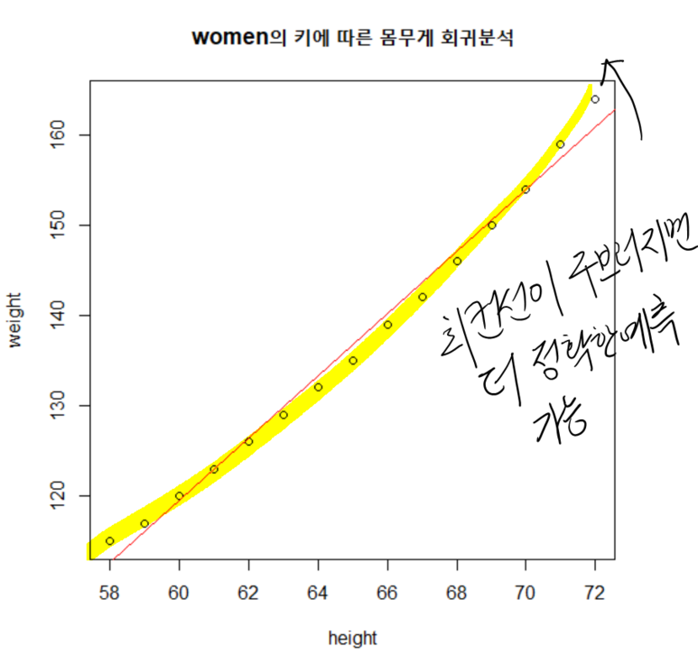

회귀분석과 요약결과

```r
fit2 <- lm(weight ~ height +I(height^2), data=women)
summary(fit2)
```

I()는 ()안의 내용을 수치적으로 계산하여 해석하라는 의미이다.

```r
fit2 <- lm(weight ~ height +I(height^2), data=women) #I()는 포뮬러 지정시 ()의 값을 수식을 있는 그대로 수치로 계산하여 해석하라는 의미
summary(fit2)
```

회귀분석 결과보고

```r
fit2 %>%
  report::report()
```

조절된 그래프

```r
plot(weight ~ height, data=women)
lines(women$height,fitted(fit2), col=2,lwd=2)
title(main="women's regression의 fit model ")
```

그래프를 보면 변수에 대하여 제곱처리를 하여 다항함수 형태로 만들면 회귀선에 대하여 좀 더 예측이 잘 되는 모델을 구성할 수 있다.

#### 5.2.1.4. 모델의 적절성 (scatterplot 이용)

이 모델이 적합한지 보는 방법으로 car{}에 들어있는 scatterplot()를 이용하여 시각적으로 확인하는 방법이다.

```r
#scatterplot
library(car)
car::scatterplot(weight ~ height, data = women,pch=19, cex=1.2,
            regLine=list(method=lm,lty=2, lwd=3,col="tomato"),
            smooth=list(smoother=loessLine, spread=FALSE, col.smooth="green3"),
            main="women Age 30 ~39")
```

이 그래프를 보면 직선 모형보다 곡선모형이 더 잘맞는 것으로 보인다.

### 5.2.2. 다중회귀분석

1. 다중 회귀분석이란

다중회귀분석은 예측변수가 두 개 이상인 경우를 말한다. 다중 회귀분석에서 예측변수의 수가 많으면 모형 선택의 과정을 거치게 된다. 회귀모형에 포함시킬 예측변수들의 선택기준은 다음과 같다. 일반적으로 다항 회귀분석은 다중 회귀분석의 특별한 경우라고 생각하면 된다.

1. 반응변수(종속변수)와의 상관관계가 높아야 한다.
2. 선택된 예측변수(독립변수)들 사이에는 상관관계가 낮아야 한다.

예측변수간에 상관관계가 높다는 것은 중복된 정보를 모형에 넣는다는 말이 된다. 또한 서로 상관이 크기 때문에 영향력 있는 예측변수를 의미없게 만든다. 이러한 것을 다중 공선성(multicolinearity)라고 한다. 보통 다중 공선성 문제를 확인할 때 VIF(variance inflation factor)값을 확인하는데 이것이 4를 넘는 것은 다중공선성 문제를 점검할 필요가 있다는 것이며, 10을 초과하면 다중공선성이 존재하는 것으로 판단한다.

참고로 다중회귀분석이나 다항회귀분석이 R에서 사용하는 fomular를 소개한다.

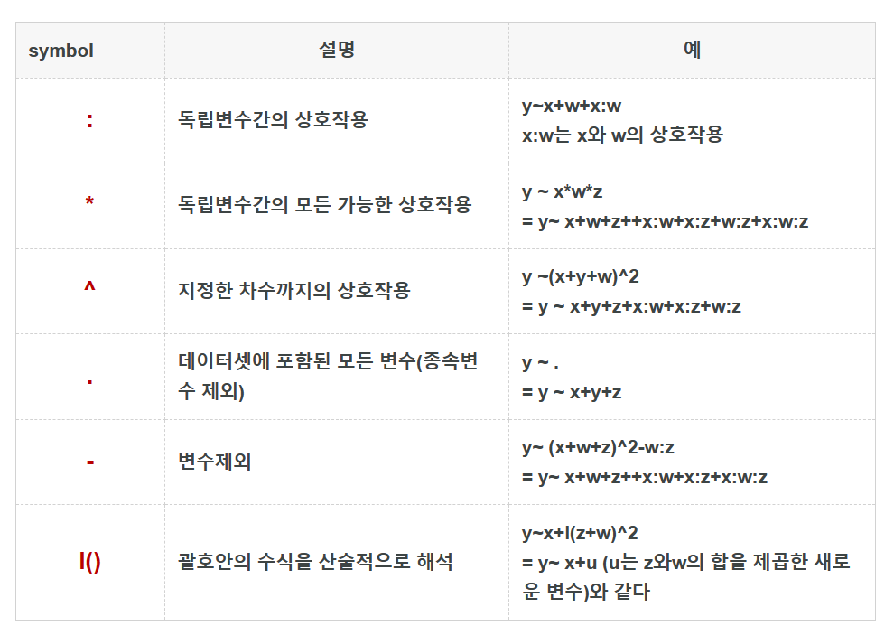

#### 5.2.2.1. 분석실습

Risk Factors Associated with Low Infant Birth Weight

The birthwt data frame has 189 rows and 10 columns. The data were collected at Baystate Medical Center, Springfield, Mass during 1986.

```r
str(birthwt)
#1986년 미국의 Messachusetts주 Springfield의  Baystate Medical Center n=189
#race 1= 엄마가 백인(white) 2 흑인, 3 그외의 경우
#race는 factor로 변환해야 함.
#bwt 반응변수
#age:djaakskdl, lwt:마지막 생리기간의 엄마의 몸무게, race(인종), smoke(임신중 흡연)
#ptl:과거 조산횟수, ht:고혈압의 기왕력, ui:uterine irritability 존재여부
```

**회귀분석**

```r
fitm <- lm(bwt ~ age+lwt+factor(race)+smoke+ptl+ht+ui, data=birthwt)
summary(fitm)
```

```r
fitm%>%
  report::report()
```

**모델의 유의성 점검 anova**

anova분석을 해보면 age, ptl은 유의하지 않게 나온다.

```r
#유의하지 않은 변수 제거를 위한 anova
anova(fitm)
```

**모델의 유의성 점검 anova**  
anova분석을 해보면 age, ptl은 유의하지 않게 나온다.

```r
#다중공선성(multicolinerity)
library(car)
car::vif(fitm)
```

```r
car::vif(fitm)>4
```

이렇게 결과에 대해서 알려주게 된다.

다중공선선 점검결과 이상없다.

```r
mtcars.lm <-lm(mpg~ hp+wt+disp+ drat, data=mtcars)
mtcars.lm  %>% summary()
```

회귀모형의 유의성

```r
mtcars.lm %>% anova()
```

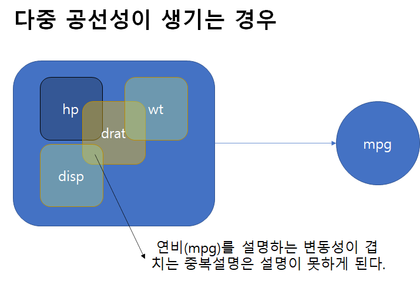

**VIF계산** 다중공선성(多重共線性)문제(Multicollinearity)는 통계학의 회귀분석에서 독립변수들 간에 강한 상관관계가 나타나는 문제이다. 독립변수들간에 정확한 선형관계가 존재하는 완전공선성의 경우와 독립변수들간에 높은 선형관계가 존재하는 다중공선성으로 구분하기도 한다. 이는 회귀분석의 전제 가정을 위배하는 것이므로 적절한 회귀분석을 위해 해결해야 하는 문제가 된다.(출처: 위키백과)  
다중공선선 문제는 회귀분석의 결과를 해석할 때 주의해야 하는 요소이다. 독립변수간에 영향을 미치고, 선형관계를 나타내는 것을 말한다. 보통 초보연구자들은 측정도구의 변수를 만들면서 이러한 문제를 잘 만들곤 하다. 예르 들어서 나이와 관련된 변수중 생일 등도 있고 연구대상이 중고등학생인데, 연령을 연결지으면 나타나는 문제들이다. 다중 회귀분석은 여러 변수가 투입되면 그 변수를 고정하여 일정하게 유지한 상태에서 관계를 측정하기 때문이다.

“다중공선성은 분산팽창지수(variance inflation facor,VIF)를 이용하여 측정한다. 이 것은 car패키지의 vif()를 이용하면 된다. 분산팽창지수는 다음과 같은 공식에 의해서 계산한다.

$$VIF=\frac{1}{1-R_i^2}$$
예측변수 i를 새로운 종속변수로 가정하고 나머지 예측변수를 새로운 예측변수로 가정하여 회귀분석을 수행하여 나타난 R-square가 바로 $R_i^2$이다. VIF는 1이상의 값을 갖게 되고, VIF=1이라는 것은 Ri2가 0이라는 의미가 된다. 그런 경우는 다중공선성이 전혀 없다는 의미이다. 그러나 만약 $R_i^2$이 증가하면 다른 예측변수들과의 상관관계가 클수록 VIF가 커지고, 다중공선성이 커지게된다.

```r
#regression
mtcars.lm <-lm(mpg~ hp+wt+disp+ drat, data=mtcars)

#multicollinearity
library(car)
vif(mtcars.lm)
```

```r
vif(mtcars.lm)>4
```

직접계산하기

```r
# hp의 vif
summary(lm(hp~wt+disp+ drat, data=mtcars))
```

[output not shown]

Multiple R-squared: 0.6545의 값을 이용하여 계산하면 된다. 결과는 위에서 구한 vif와 동일하다

```r
1/(1-0.6545)
```

상관관계 체크

```r
# 상관관계 체크
MTC <-mtcars %>%
  dplyr::select(mpg, hp, wt, disp, drat)
library(PerformanceAnalytics)
chart.Correlation(MTC)
```

**모델개선**

모델을 개선하기 위해서 유의하지 않은 두개의 변수 (0age, ptl)을 제거하여 다시 회귀모델을 만들어보자

```r
fitm2 <- lm(bwt ~ lwt+factor(race)+smoke+ht+ui, data=birthwt)
fitm2 %>% summary()
```

fitm2는 변수가 제거된 모델로 분석이 되었다. 그렇다면 anova를 이용하여 fitm과 fitm2를 비교해보자. anova(작은 모형, 큰 모형)순으로 넣어서 비교해 보자.

```r
anova(fitm2)
```

**모델비교**  
로그우도비 테스트 (Likelood Ratio test; LR)

로그우도비테스트는 두개의 모형의 우도(가능도)의 비율을 계산해서 두 모형의 우도가 유의하게 차이나는지 검정하는 방법이다. 모수로부터 특정한 현상이 나타나고 그것을 관찰하는 것을 확률적 개념이라고 한다. 우도(likehood)는 주어진 현상이 나타날 가능성이 가장 높은 모수를 거꾸로 추적하는 방법이고 이를 최대우도법이라고 한다.

모델을 비교하는 방법으로는 로그우도비 테스트(anova()을 이용)하여 유의한 차이가 있는지 확인하여 간명성을 유지하는 모델을 선택한다. 로그우도비 테스트는 분산분석을 이용하여 비교하는 방법으로 모델이 중첩이 된 경우만 비교가 가능하다.

anova()를 이용한 분석  
anova()함수는 wald test이다. Compute analysis of variance (or deviance) tables for one or more fitted model objects.

참고: Chambers, J. M. and Hastie, T. J. (1992) Statistical Models in S, Wadsworth & Brooks/Cole

```r
anova(fitm2, fitm)
```

[output not shown]

이렇게 두 개의 모형을 비교해보면 F test결과 p값이 0.792로 매우크다.  
조절된 모형의 anova이다.

**AIC 이용한 비교**

AIC는 Akaike information criterian을 말하면 이 지표는 모델의 적합도와 parameter개수를 고려하는 모델로, 그 값이 작은 것이 더 적합하고 우수한 모델로 평가한다. AIC()함수를 이용하여 비교한다.

```r
AIC(fitm2, fitm)
```

```r
fitm2 %>%
  report::report()
```

R^2설명력이 24%에 해당한다. 통제가 쉽지않는 변인이 많은 연구에서는 작은 수는 아니다.

```r
# sjPlot::tab_model(fitm, fitm2,
#                   show.ci = FALSE,
#             show.df = FALSE,
#             show.aic = TRUE,
#             show.loglik = TRUE,
#             p.style = "star")

stargazer::stargazer(fitm2,fitm, type="text")
```

### 5.2.3.로지스틱 회귀분석

로지스틱 회귀분석은 종속변수가 이항변수인 경우 사용한다. 다른 포스팅을 통하여 이미 설명한 내용들이 많아서 실행하는 것을 중심으로 설명하였다. 로지스틱 회귀분석을 회귀분석의 결과인 종속변수가 0아니면 1이기 때문에 로그변환한 수식을 활용한다. 이때 오즈비을 사용한다. 오즈비는 $odd = \frac{p}{1-p}$로 계산되는데, p는 사건이 일어날 확률이므로 1-p는 사건이 일어나지 않을 확률이다. 예를 들어서 남여 10명이 있다고 하자. 남자는 4명, 여자는 6명이 있다면 전체중 남자의 비율은 0.4가 된다. 그런데 여자와 비교한 남자의 수는 4/6=2/3이 된다. 이러한 것을 오즈비라고 생각하면 될듯 하다.

colon 데이터는 colom cancer 1858명의 데이터이다.

```r
library(survival)
str(colon)
```

na.omit() 함수는 행 단위로 어떤 결측치라도 있으면 이 행을 제거하고 남은 데이터를 반환한다.

```r
colon <- na.omit(colon)
```

Format id: id  
study: 1 for all patients  
rx: Treatment - Obs(ervation), Lev(amisole), Lev(amisole)+5-FU  
sex: 1=male  
age: in years  
obstruct: obstruction of colon by tumour  
perfor: perforation of colon  
adhere: adherence to nearby organs  
nodes: number of lymph nodes with detectable cancer  
time: days until event or censoring  
status: censoring status  
differ: differentiation of tumour (1=well, 2=moderate, 3=poor)  
extent: Extent of local spread (1=submucosa, 2=muscle, 3=serosa, 4=contiguous structures)  
surg: time from surgery to registration (0=short, 1=long)  
node4: more than 4 positive lymph nodes  
etype: event type: 1=recurrence,2=death

**로지스틱 회귀 분석**

회귀분석은 glm()을 이용한다. 종속변수 ~ 독립변수+독립변수2+…, fmaily=binomial을 추가하여 로지스틱회귀분석을 하는 것을 체크하다. 여기에는 포아송등 다양한 변수가 들어갈 수 있다.

```r
result <- glm(status ~rx+sex+age+obstruct+perfor+adhere+nodes+differ+extent+surg,
              family= binomial, data=colon)
summary(result)
```

stepwise logistic regression

```r
#stepwise logistic regression
reduced.model = step(result)
```

```r
summary(reduced.model)
```

```r
stargazer::stargazer(reduced.model, type= "text")
```

**오즈비**  
오즈비는 그냥 계산해도 되지만 moonBook패키지를 사용하면 더 쉽게 계산된다. 여담이지만 문건웅 교수님이 개발한 moonBook, mytable, ztable은 분석을 하고 사용하면 할수록 대단하고 고맙다는 마음이 들게 만드는 것 같다.

```r
library(moonBook)
extractOR(reduced.model)
```

**오즈비 plot**  
오즈비를 시각화하여 보여주는 도구이다. moonBook packages에 있는 도구를 사용하면 된다.

```r
ORplot(reduced.model, type=2,show.OR = FALSE, show.CI = TRUE,
       pch=15, lwd=3,
       col=c("blue","red"),
       main="plot for odds ratios if reduced model")
```

오즈비 플롯

```r
ORplot(reduced.model, type = 3, show.CI = TRUE,
       main="plot for odds ratios if reduced model")
```

## 5.3. 회귀계수의 차이 검증 Wald test

회귀계수를 비교하는 방법을 알아보고자 한다. 회귀분석후에 분석된 결과를 보면서 확인해보자.

```r
lm(mpg ~ hp+ wt+ disp, mtcars) %>% summary()
```

[output not shown]

hp의 계수 -0.031157와 wt의 계수 -3.800891는 각각 유의한 값으로 나타났다.

```r
lm(mpg ~ hp+ wt+ disp, mtcars) %>%
  lm.beta::lm.beta() %>%   summary()
```

```r
lm(mpg ~ hp+ wt+ disp, mtcars) %>% tidy(conf.int = TRUE)
```

```r
lm(mpg ~ hp+ wt+ disp, mtcars) %>%
  tidy(conf.int = TRUE) %>%
     confint_mark_sig() %>%
  Round(2)
```

이제 두 회귀계수와 표준 오차를 입력하여 두 계수가 유의한 차이가 나는지 확인해보자.  
첫번째는 wald_test(z-test)라고 불리는 방법을 사용하여 확인하는 방법이다.

```r
wald_test(b1=-0.031, se1=0.011, b2=-3.801 ,se2=1.066    , type="res")
```

어쩌다 한번 확인하는 것은 쉽게 되지만 여러번 하게 되면 헷갈리게 된다. 이럴때에는 안정하게 명확한 이름을 입력하는게 좋다.  
type= “res2”로 하여 모든 결과가 나타나게 하고, 변수명을 입력하여 결과를 확인해보자.

```r
wald_test(b1=-0.031, se1=0.011, b2=-3.801 ,se2=1.066, type="res2",
          est1 = "hp", est2 = "wt")
```

논문에서 나타난 데이터만 보고 두개의 회귀계수의 wald_test를 하려고 하다보면, 표준오차는 없고 t값만 존재하는 경우가 있다. 이런 경우에는 wald_test2()함수를 사용하고 표준오차 위치에 t값을 입력하여 계산하면된다.

```r
wald_test2(b1=-0.031, t1=-2.724, b2=-3.801 , t2=-3.565, type = "res2")
```

데이터를 검증하는 것이 아니라 직접 회귀계수를 구한 경우에는 wald_test_df()를 이용하여 값을 입력하는 것이 아니라 변수가 존재하는 행의 번호를 대입하여 직접 구할 수도 있다.

```r
lm(mpg ~ hp+ wt+ disp, mtcars) %>%
  wald_test_df(row1= 2,row2 =3) %>%
  p_mark_sig(unite=T)
```

위에서 구한 값과 차이가 나는 이유는 위에서는 소수점 자리 절삭(rounding)처리를 해서 입력한 것이고, 이 값은 실제 값을 입력해서 나타난 것이기때문에 물론 이 값이 더 정확한 값이다.

이것을 시각화해서 알아보자. 신뢰구간을 알아보자. disp는 0을 포함하는 구간이므로 유의하지 않다.

```r
lm(mpg ~ hp+ wt+ disp, mtcars) %>% confint()
```

그리고, 여기에서 하나 알게되는 것이 hp와 wt의 신뢰구간을 보면 겹치지 않는 것을 확인할 수 있다. 이렇게 겹치지 않는 데이터는 통계적으로 유의한 차이가 난다고 할 수 있다. 이를 시각화해서 확인해보자.

```r
lm(mpg ~ hp+ wt+ disp, mtcars) %>%
  confint_plot_lm()
```

이제 wt와 disp가 통계적으로 유의한 차이가 나는지 확인해보자.  
유의성 그림에서는 hp와 disp가 0에 가깝고, 범위가 좁아서 확인이 쉽지 않지만, 신뢰구간을 확인해보면 쉽게 알 수 있다. tidy()함수에서 conf.int=TRUE를 하면 신뢰구간이 함께 포함된다.

```r
lm(mpg ~ hp+ wt+ disp, mtcars) %>%
  tidy(conf.int=TRUE) %>%
  # select(1,3,4,5,6,7) %>%
  p_mark_sig()
```

이번에는 wt와 disp의 계수가 유의한 차이가 있는지 알아보자.  
우리가 알아보는 가설은 다음과 같다.

H0: wt - disp = 0  
H1: wt - disp $\gt$ 0

이를 검증해보려고 한다.

```r
lm(mpg ~ hp+ wt+ disp, mtcars) %>%
  wald_test_df(row1= 3, row2 = 4) %>%
  p_mark_sig(unite=T)
```

분석결과 두 계수의 차이는 통계적으로 유의하였다.

그런데, 어떤 독자는 이러한 것을 제시할 수 있다. wt계수는 통계적으로 유의한 계수이고, disp는 통계적으로 유의하지 않은 계수이다. 그런데 유의한 것과 유의하지 않은 것을 비교할 수 있는가? 물론 가능하다. 왜냐면 각각의 계수의 유의하다는 것과 계수의 차이가 유의하다는 것은 다르기 때문이다.

두 계수의 경우를 보면 다음과 같다.

```
경우1 : 유의함  - 유의함
경우2 : 유의함  - 유의하지 않음
경우3 : 유의하지 않음 - 유의함
경우4 : 유의하지 않음 - 유의하지 않음
```

이러한 모든 경우가 차이에 대한 유의성 검정이 가능하다.

# 6. 응용통계분석(1)

## 6.1. 경로 분석

## 6.2. 매개효과 분석

## 6.3. 조절효과 분석(상호작용효과분석)

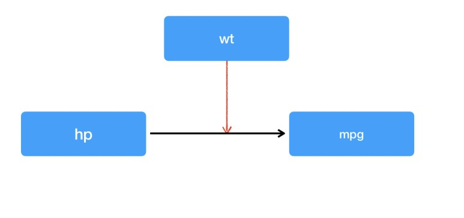

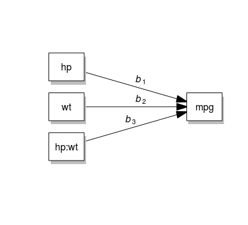

```r
fit  = lm(mpg ~ hp+wt+hp:wt, data= mtcars)
summary(fit)
```

마력(hp)과 무게(wt)의 상호작용항은 유의하였다.

```r
library(effects)
m <- round(mean(mtcars$wt),1);m
s <- round(sd(mtcars$wt),1);s

plot(effect(term="hp:wt", mod=fit, xlevels=list(wt=c(m-s,m,m+s))),
lines=list(multiline=TRUE, lwd=2,lty=c(3,2,1),
col=c("red","blue","darkgreen")),
main="interaction plot For hp and wt")
```

차량의 무게(wt)가 증가할 수록 상호작용효과는 나타나지 않고 있다.

predict3d패키지를 이용하면 더 명확한 그래프를 더 쉽게 얻어진다.

이 그래프에서는 상호작용 효과가 나타나는 기울기에서 볼 수 있듯이 무게가 증가함에 따라서 연비에 대한 상호작용효과는 거의 나타나지 않음을 알 수 있다.

```r
library(predict3d)
ggPredict(fit)
```

상호작용을 탐색하려면 조절변수wt를선택하여 mpg에대한 hp의 조건부 효과를 구해야 한다. 차후에 자세히 다시 한번 설명하기로 하고 이를 조건부로 구한 것을 보도록 하자.  
조절변수를 넣어서 표준오차의 추정량을 표시하였다.  
특정한 wt의 값에서 $\theta_{(X->Y)} = 0$ 을 귀무가설로 검증하게 된다. $df_{residuals}$ , t분포에 따르기 때문에 t분포에서 p값을 구하여 유의성을 확인한다.

$$\theta _{X\ ->Y}\
=\sqrt{se_{b1}^2+\left(2wt\right)COV_{b1b3}+wt^2se_{b3}^2}$$

## 6.4. Process Macro

# 7. 구조방정식 모형

### 7.1. 데이터의 구조의 적합성 및 기술 통계

```r
sats<- jjstat::sats
str(sats)
```

```r
#전체의 평균을 구해보는 함수
sats %>% summarise_all(mean)
```

tidyvers에는 purrr이라는 패키지가 포함되어있다. for문을 이용하여 반복을 처리하는 것에 대하여 for를 사용하지 않고도 반복을 처리하는데 특화된 패키지이다. 이중에 discard()는 지정한 옵션을 제외하라는 것으로 사용되고, keep()는 지정한 것을 사용하는 것으로 사용되며, map_dbl(x, f)은 반복문을 처리하는 함수이다. f는 함수인데, 직접 지정하는 것도 가능하다.

이제 numeric변수만을 추출해서 구해보자.

```r
# method 1
sats%>%
  discard(is.factor) %>%
  map_dbl(mean)
```

keep()를 이용하는 방법이다.

```r
# method 1
sats%>%
  keep(is.numeric) %>%
  map_dbl(mean)
```

여러가지 통계치를 한번에 얻으려면 jjstat패키지의 mysummary를 이용한다.  
먼저 데이터에서 numeric변수를 keep()를 이용하여 추출한 후에 적용하면 되는데, 이미 변수들이 선택되었으므로 모든 변수의 이름을 colnames(.)으로 한다. ‘.’ 은 all을 나타낸다(at tidyverse). Round{jjsat}는 chr, factor변수를 제외한 나머지 numeric변수만을 선택하여 round처리를 해주는 함수이다.

```r
sats%>%
  keep(is.numeric) %>%
  mysummary(colnames(.)) %>%
  Round(2)
```

mysummary에서 all=TRUE로 하면 numeric변수만을 찾아서 모든 변수에 대한 기술통계를 나타내준다.

```r
#
sats%>% mysummary()
```

이렇게 데이터의 구조와 기술통계를 확인하는 것은 데이터가 분석을 하기에 적합한 정규성을 가지고 있는지 확인하기 위함이다.

## 7.2. SEM을 이용한 회귀

# 8. PLS 구조 방정식 모형

# 9. 혼합모형(다층모형) 분석

# 10. 다변량 분석

## 10.1.주성분 분석

## 10.2.인자분석

## 10.3. 다차원 척도법

## 10.4. 대응일치분석

## 10.5. 군집 분석

## 10.6. 잠재프로파일 분석

## 10.7. 형상 분석

## 10.8. 소셜네트워크 분석

## 10.9. 연관분석

# Reference

- Creswell, J. W. (2014). Research design: Qualitative, quantitative, and mixed methods approaches (4th ed.). Thousand Oaks, CA: Sage publications.
- Hair, J. F., Jr., Hult, G. T. M., Ringle, C. M., & Sarstedt, M. (2017). A primer on partial least squares structural equation modeling (PLS-SEM). Thousand Oaks, CA: Sage publications.
- Levene, H. (1960). Robust tests for equality of variances. Contributions to probability and statistics, 278-292.
- Fligner, M. A., & Killeen, T. J. (1976). Distribution of the F statistic for the Kruskal-Wallis one-way analysis of variance. Journal of the American Statistical Association, 71(353), 207-210.
- Cronbach, L. J. (1951). Coefficient alpha and the internal structure of tests. Psychometrika, 16(3), 297-334.
- Tavakol, M., & Dennick, R. (2011). Making sense of Cronbach’s alpha. International journal of medical education, 2, 53.
- Razali, N. M., & Wah, Y. B. (2011). Power comparisons of shapiro-wilk, kolmogorov-smirnov, lilliefors and anderson-darling tests. Journal of statistical modeling and analytics, 2(1), 21-33.
- Dawson, Robert J. MacG. (1995), The ‘Unusual Episode’ Data Revisited. Journal of Statistics Education, 3. doi:10.1080/10691898.1995.11910499.
- British Board of Trade (1990), Report on the Loss of the ‘Titanic’ (S.S.). British Board of Trade Inquiry Report (reprint). Gloucester, UK: Allan Sutton Publishing.
- D. N. Joanes and C. A. Gill (1998), Comparing measures of sample skewness and kurtosis. The Statistician, 47, 183–189.
- Bartlett, M. S. (1937). The statistical conception of mental factors. British Journal of Psychology, 28, 97–104. doi:10.1111/j.2044-8295.1937.tb00863.x.
- Bartlett, M. S. (1938). Methods of estimating mental factors. Nature, 141, 609–610. doi:10.1038/141246a0.
- Jöreskog, K. G. (1963). Statistical Estimation in Factor Analysis. Almqvist and Wicksell.
- Mardia, K.V., Kent, J.T., and Bibby, J.M. (1979). Multivariate Analysis. Academic Press, London.
- Lawley, D. N. and Maxwell, A. E. (1971). Factor Analysis as a Statistical Method. Second edition. Butterworths.
- Thomson, G. H. (1951). The Factorial Analysis of Human Ability. London University Press.
- D. J. Hand, F. Daly, A. D. Lunn, K. J. McConway and E. Ostrowski (1994). A Handbook of Small Datasets, Chapman and Hall/CRC, London.
- Krzanowski, W. J. (1988) Principles of Multivariate Analysis. A User’s Perspective. Oxford.
- Hand, D. J. and Taylor, C. C. (1987) Multivariate Analysis of Variance and Repeated Measures. Chapman and Hall.